# HAT-GOE-Monitor-Code

### 9.1.2 ??? Biomass Removed Per Time Investment

- would I need to group and add up total crew hours and biomass removed ???

```r
colnames(crew_data_sep_sub)
```

```
## [1] "Year"                     "Work_Site"
## [3] "Location"                 "Area_Cleared_m2"
## [5] "Biomass_Removed_m3"       "Invasive_Species_Cleared"
## [7] "Crew_Hours"               "Notes"
## [9] "Date"
```

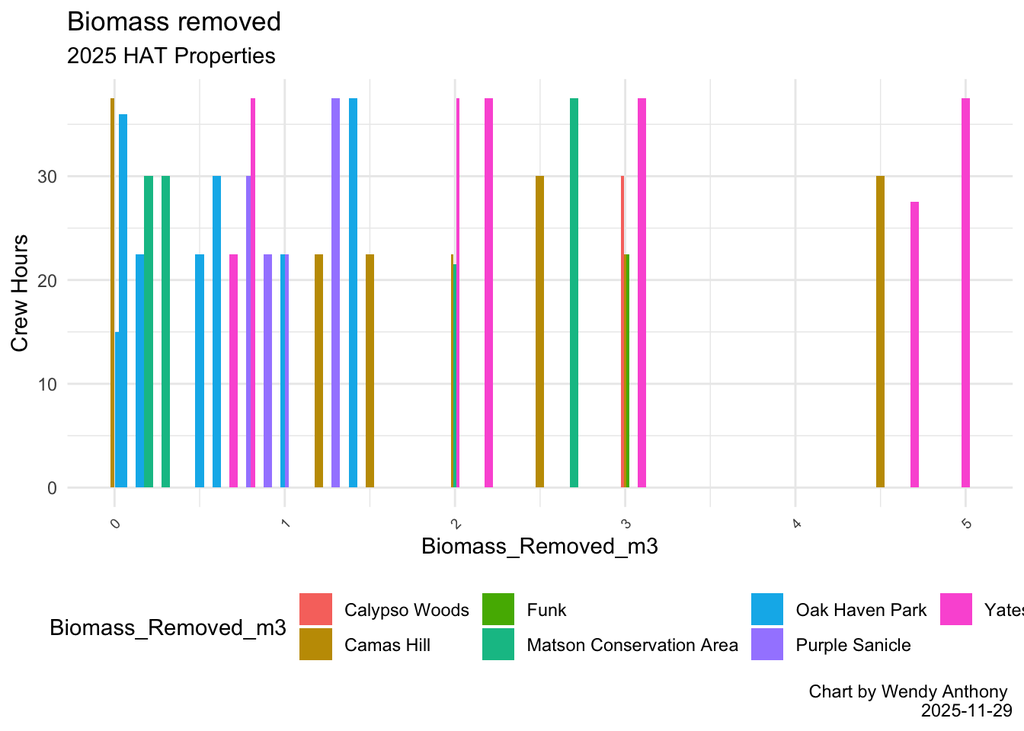

```r
# Filter by year - need column for year
crew_data_sep_sub_2025 <- crew_data_sep_sub[crew_data_sep_sub$Year == "2025",]

crew_data_sep_sub_2025_plot <-
  ggplot(crew_data_sep_sub_2025, aes(x = Biomass_Removed_m3, y = Crew_Hours, fill = Work_Site)) +
  geom_bar(stat = "identity", width = 0.05, position = "dodge") +
  theme_minimal() + #get rid of grey background and tick marks
  theme(legend.position ="bottom") +
  theme(axis.text.x = element_text(angle = 45, vjust = 1, hjust=1, size = 7)) +
    #scale_fill_manual(values = custom_colours_3) +
        labs(title='Biomass removed',
          subtitle='2025 HAT Properties',
          caption = "Chart by Wendy Anthony \n 2025-11-29", fill = "Biomass_Removed_m3",
          x = "Biomass_Removed_m3", y = "Crew Hours")

crew_data_sep_sub_2025_plot
```

```r
# ggsave(filename = paste0("images/crew_data_sep_sub_2025_plotĆ_", format(Sys.time(), "%Y-%m-%d_%H.%M"),".png"), crew_data_sep_sub_2025_plot)
```

### 9.1.3 **** Group by Work Site and add work hours and biomass removed

```r
colnames(crew_data_sep_sub)
```

```
## [1] "Year"                     "Work_Site"
## [3] "Location"                 "Area_Cleared_m2"
## [5] "Biomass_Removed_m3"       "Invasive_Species_Cleared"
## [7] "Crew_Hours"               "Notes"
## [9] "Date"
```

```r
str(crew_data_sep_sub)
```

```
## 'data.frame':    173 obs. of  9 variables:
##  $ Year                    : int  2023 2024 2024 2023 2023 2023 2023 2023 2023 2023 ...
##  $ Work_Site               : chr  "Matson Conservation Area" "Matson Conservation Area" "Matson Conservation Area" "Oak Haven Park" ...
##  $ Location                : chr  "https://maps.app.goo.gl/MN9fpJThnJ7iHBCs13" "https://maps.app.goo.gl/MN9fpJThnJ7iHBCs9" "https://maps.app.goo.gl/MN9fpJThnJ7iHBCs9" "1254 Garden Gate Dr, Brentwood Bay, BC V8M 2H6" ...
##  $ Area_Cleared_m2         : num  75 83.7 54.5 30 200 150 22000 1000 22000 45 ...
##  $ Biomass_Removed_m3      : num  2.5 0.8 0.5 2.5 0.75 1.9 2 2.5 1.75 0.8 ...
##  $ Invasive_Species_Cleared: chr  "English ivy, Himalayan blackberry" "Orchardgrass, thatch " "Thatch " "Daphne" ...
##  $ Crew_Hours              : num  37.5 38 22.5 15 30 27.5 30 37.5 34 15 ...
##  $ Notes                   : chr  "ĆENŦEḴI New Moon event at Matson - w/ UVic Class" "1st round of mowing in 2 deer exclosures,  orchard grass removal in open meadow areas, completed fencing in dee"| __truncated__ "2nd round of mowing in deer Exclosure #1, completed fencing for deer Exclosure #2,…
##  $ Date                    : Date, format: "2023-06-19" "2024-10-08" ...
```

```r
# aggregate(crew_data_sep_sub$Work_Site, by=list(Biomass_Removed_m3=crew_data_sep_sub$Biomass_Removed_m3), FUN=sum)
## Error in FUN(X[[i]], ...) : invalid 'type' (character) of argument

crew_data_sep_sub_sum_by_group_site <- crew_data_sep_sub %>%
  group_by(Work_Site, Year) %>%
  summarise(Biomass_Removed_m3 = sum(Biomass_Removed_m3),
            Crew_Hours = sum(Crew_Hours))
crew_data_sep_sub_sum_by_group_site
```

```
## # A tibble: 23 × 4
## # Groups:   Work_Site [9]
##    Work_Site       Year Biomass_Removed_m3 Crew_Hours
##    <chr>          <int>              <dbl>      <dbl>
##  1 Bear Hill       2024               33         68
##  2 Calypso Woods   2025                3         30
##  3 Camas Hill      2023               59        258
##  4 Camas Hill      2024                8.8      120
##  5 Camas Hill      2025               14.7      188.
##  6 Funk            2023                5         34.5
##  7 Funk            2024                4         30
##  8 Funk            2025                3         22.5
##  9 Havenwood Park  2023               15         37.5
## 10 Havenwood Park  2024                2.5       30
## # ℹ 13 more rows
```

### 9.1.4 *** Total Biomass Removed Per Time Investment

- group and add up total crew hours and biomass removed

```r
colnames(crew_data_sep_sub_sum_by_group_site)
```

```
## [1] "Work_Site"          "Year"               "Biomass_Removed_m3"
## [4] "Crew_Hours"
```

```r
# [1] "Work_Site"          "Year"               "Biomass_Removed_m3" "Crew_Hours"

unique(crew_data_sep_sub_sum_by_group_site$Work_Site)
```

```
## [1] "Bear Hill"                "Calypso Woods"
## [3] "Camas Hill"               "Funk"
## [5] "Havenwood Park"           "Matson Conservation Area"
## [7] "Oak Haven Park"           "Purple Sanicle"
## [9] "Yates"
```

[figure not shown]

```r
# Filter by year - need column for year
crew_data_sep_sub_sum_by_group_site_2025 <- crew_data_sep_sub_sum_by_group_site[crew_data_sep_sub_sum_by_group_site$Year == "2025",]

crew_data_sep_sub_sum_by_group_site_2025_plot <-
  ggplot(crew_data_sep_sub_sum_by_group_site_2025, aes(x = Crew_Hours, y = Biomass_Removed_m3, fill = Work_Site)) +
#  ggplot(crew_data_sep_sub_sum_by_group_site_2025, aes(x = Biomass_Removed_m3, y = Crew_Hours, fill = Work_Site)) +
  geom_bar(stat = "identity", width = 5, position = "dodge") +
  theme_minimal() + #get rid of grey background and tick marks
  theme(legend.position ="bottom") +
  theme(axis.text.x = element_text(angle = 0, vjust = 1, hjust=1, size = 7)) +
    #scale_fill_manual(values = custom_colours_3) +
        labs(title='Total Biomass Removed and Work Crew Hours',
          subtitle='2025 HAT Properties',
          caption = "Chart by Wendy Anthony \n 2025-11-29", fill = "Work_Site",
          x = "Biomass Removed (m3)", y = "Crew Hours") +
  guides(fill = guide_legend(title="Work Site"))

crew_data_sep_sub_sum_by_group_site_2025_plot
```

```r
# ggsave(filename = paste0("images/crew_data_sep_sub_2025_plotĆ_", format(Sys.time(), "%Y-%m-%d_%H.%M"),".png"), crew_data_sep_sub_2025_plot)
```

### 9.1.5 Biomass Removed

```r
str(crew_data_sep_sub)
```

```
## 'data.frame':    173 obs. of  9 variables:
##  $ Year                    : int  2023 2024 2024 2023 2023 2023 2023 2023 2023 2023 ...
##  $ Work_Site               : chr  "Matson Conservation Area" "Matson Conservation Area" "Matson Conservation Area" "Oak Haven Park" ...
##  $ Location                : chr  "https://maps.app.goo.gl/MN9fpJThnJ7iHBCs13" "https://maps.app.goo.gl/MN9fpJThnJ7iHBCs9" "https://maps.app.goo.gl/MN9fpJThnJ7iHBCs9" "1254 Garden Gate Dr, Brentwood Bay, BC V8M 2H6" ...
##  $ Area_Cleared_m2         : num  75 83.7 54.5 30 200 150 22000 1000 22000 45 ...
##  $ Biomass_Removed_m3      : num  2.5 0.8 0.5 2.5 0.75 1.9 2 2.5 1.75 0.8 ...
##  $ Invasive_Species_Cleared: chr  "English ivy, Himalayan blackberry" "Orchardgrass, thatch " "Thatch " "Daphne" ...
##  $ Crew_Hours              : num  37.5 38 22.5 15 30 27.5 30 37.5 34 15 ...
##  $ Notes                   : chr  "ĆENŦEḴI New Moon event at Matson - w/ UVic Class" "1st round of mowing in 2 deer exclosures,  orchard grass removal in open meadow areas, completed fencing in dee"| __truncated__ "2nd round of mowing in deer Exclosure #1, completed fencing for deer Exclosure #2,…
##  $ Date                    : Date, format: "2023-06-19" "2024-10-08" ...
```

```r
colnames(crew_data_sep_sub)
```

```
## [1] "Year"                     "Work_Site"
## [3] "Location"                 "Area_Cleared_m2"
## [5] "Biomass_Removed_m3"       "Invasive_Species_Cleared"
## [7] "Crew_Hours"               "Notes"
## [9] "Date"
```

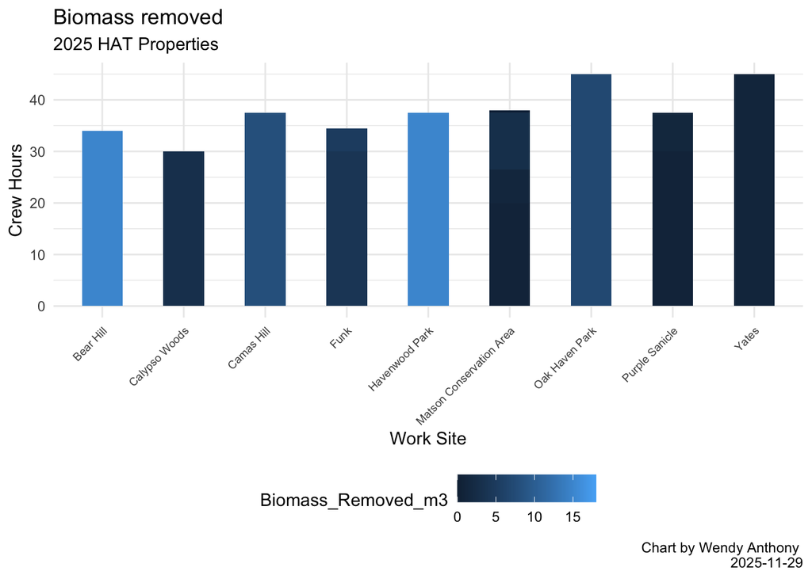

```r
# create custom colour-blind-friendly palette
custom_colours_3 <- c("Invasive" = "#fc8d62",
                    "Native" = "#66c2a5",
                    "MixedGrass" = "#8da0cb")
# custom_colours_3 <- c("Native" = "#1b9e77",
#                     "Invasive" = "#d95f02",
#                     "MixedGrass" = "#7570b3")

crew_data_sep_sub_plot <-
  ggplot(crew_data_sep_sub, aes(x = Work_Site, y = Crew_Hours, fill = Biomass_Removed_m3)) +
  geom_bar(stat = "identity", width = 0.5, position = "dodge") +
  theme_minimal() + #get rid of grey background and tick marks
  theme(legend.position ="bottom") +
  theme(axis.text.x = element_text(angle = 45, vjust = 1, hjust=1, size = 7)) +
    #scale_fill_manual(values = custom_colours_3) +
        labs(title='Biomass removed',
          subtitle='2025 HAT Properties',
          caption = "Chart by Wendy Anthony \n 2025-11-29", fill = "Biomass_Removed_m3",
          x = "Work Site", y = "Crew Hours")

crew_data_sep_sub_plot
```

```r
# ggsave(filename = paste0("images/crew_data_sep_sub_plot_W̱SÁNEĆ_", format(Sys.time(), "%Y-%m-%d_%H.%M"),".png"), crew_data_sep_sub_plot)
```

### 9.1.6 *** Staff Hours Metric

```r
colnames(HAT_data_inv_site_metrics)
```

```
## [1] "Work_Site"    "Hours"        "Days"         "Area"         "Biomass"
## [6] "Site_Num"     "Site"         "Partner_Code"
```

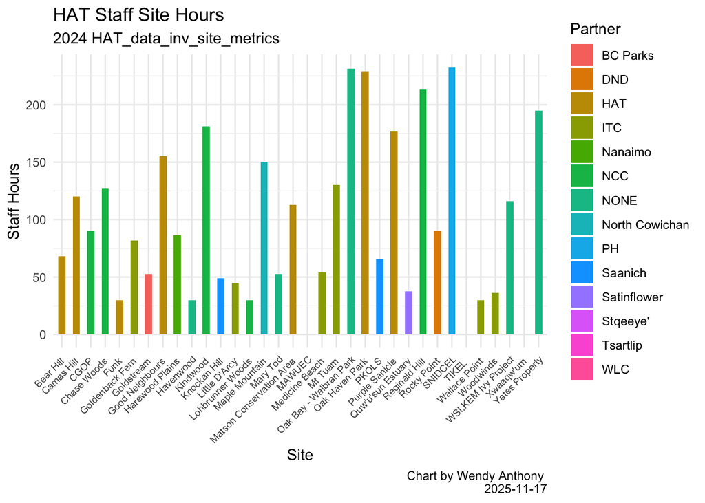

```r
# drop row with data not shared
HAT_data_inv_site_metrics <- HAT_data_inv_site_metrics[!(HAT_data_inv_site_metrics$Site %in% "NOT-SHARED"),]

HAT_data_inv_site_metrics_staffhrs <- ggplot(HAT_data_inv_site_metrics,
   aes(x = Site, y = Hours, fill = Partner_Code)) +
#  aes(x = Site, y = Hours)) +
  geom_bar(stat = "identity", width = 0.5, position = "dodge") +
  theme_minimal() + #get rid of grey background and tick marks
  theme(legend.position ="right") +
  theme(axis.text.x = element_text(angle = 45, vjust = 1, hjust=1, size = 7)) +
    # scale_fill_manual(values = custom_colours_4) +
        labs(title='HAT Staff Site Hours',
          subtitle='2024 HAT_data_inv_site_metrics',
          caption = "Chart by Wendy Anthony \n 2025-11-17", fill = "Partner",
#         caption = "Chart by Wendy Anthony \n 2025-11-17", fill = "",
          x = "Site", y = "Staff Hours")

HAT_data_inv_site_metrics_staffhrs
```

```r
# ggsave(filename = paste0("images/HAT_data_inv_site_metrics_staffhrs_plot_", format(Sys.time(), "%Y-%m-%d_%H.%M"),".png"), HAT_data_inv_site_metrics_staffhrs)
```

### 9.1.7 Volunteer Hours

```r
colnames(HAT_data_Volevents)
```

```
## [1] "Date"            "Event"           "Partner"         "Volunteers"
## [5] "Volunteer_Hours" "Notes"           "Year"
```

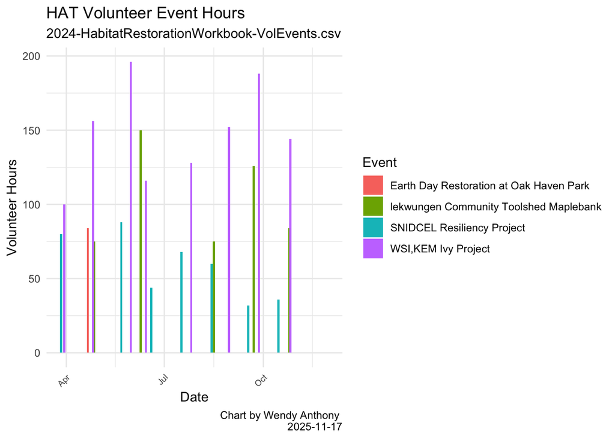

```r
HAT_data_Volevents_2024 <- HAT_data_Volevents[!(HAT_data_Volevents$Year %in% "2023"),]

HAT_data_Volevents_2024 <- ggplot(HAT_data_Volevents_2024,
   aes(x = Date, y = Volunteer_Hours, fill = Event)) +
#  aes(x = Site, y = Hours)) +
  geom_bar(stat = "identity", width = 2, position = "dodge") +
  theme_minimal() + #get rid of grey background and tick marks
  theme(legend.position ="right") +
  theme(axis.text.x = element_text(angle = 45, vjust = 1, hjust=1, size = 7)) +
    # scale_fill_manual(values = custom_colours_4) +
        labs(title='HAT Volunteer Event Hours',
          subtitle='2024-HabitatRestorationWorkbook-VolEvents.csv',
          caption = "Chart by Wendy Anthony \n 2025-11-17", fill = "Event",
#         caption = "Chart by Wendy Anthony \n 2025-11-17", fill = "",
          x = "Date", y = "Volunteer Hours")

HAT_data_Volevents_2024
```

```r
# Warning
# `position_dodge()` requires non-overlapping x intervals

# ggsave(filename = paste0("images/HAT_data_Volevents_2024_plot_", format(Sys.time(), "%Y-%m-%d_%H.%M"),".png"), HAT_data_Volevents_2024)
```

### 9.1.8 ??? Volunteer Events

```r
colnames(HAT_data_Volevents)
```

```
## [1] "Date"            "Event"           "Partner"         "Volunteers"
## [5] "Volunteer_Hours" "Notes"           "Year"
```

```r
str(HAT_data_Volevents)
```

```
## 'data.frame':    27 obs. of  7 variables:
##  $ Date           : Date, format: "2024-04-21" "2023-12-01" ...
##  $ Event          : chr  "Earth Day Restoration at Oak Haven Park" "lekwungen Community Toolshed Maplebank" "lekwungen Community Toolshed Maplebank" "lekwungen Community Toolshed Maplebank" ...
##  $ Partner        : chr  "Central Saanich" "Cheryl Bryce" "Cheryl Bryce" "Cheryl Bryce" ...
##  $ Volunteers     : int  21 40 25 50 25 42 28 0 20 22 ...
##  $ Volunteer_Hours: int  84 120 75 150 75 126 84 0 80 88 ...
##  $ Notes          : chr  "" "" "" "" ...
##  $ Year           : chr  "2024" "2023" "2024" "2024" ...
```

```r
HAT_data_Volevents$Date <- as.Date(HAT_data_Volevents$Date)
str(HAT_data_Volevents)
```

```
## 'data.frame':    27 obs. of  7 variables:
##  $ Date           : Date, format: "2024-04-21" "2023-12-01" ...
##  $ Event          : chr  "Earth Day Restoration at Oak Haven Park" "lekwungen Community Toolshed Maplebank" "lekwungen Community Toolshed Maplebank" "lekwungen Community Toolshed Maplebank" ...
##  $ Partner        : chr  "Central Saanich" "Cheryl Bryce" "Cheryl Bryce" "Cheryl Bryce" ...
##  $ Volunteers     : int  21 40 25 50 25 42 28 0 20 22 ...
##  $ Volunteer_Hours: int  84 120 75 150 75 126 84 0 80 88 ...
##  $ Notes          : chr  "" "" "" "" ...
##  $ Year           : chr  "2024" "2023" "2024" "2024" ...
```

```r
unique(HAT_data_Volevents$Event)
```

```
## [1] "Earth Day Restoration at Oak Haven Park"
## [2] "lekwungen Community Toolshed Maplebank"
## [3] "SNIDCEL Resiliency Project"
## [4] "WSI,KEM Ivy Project"
```

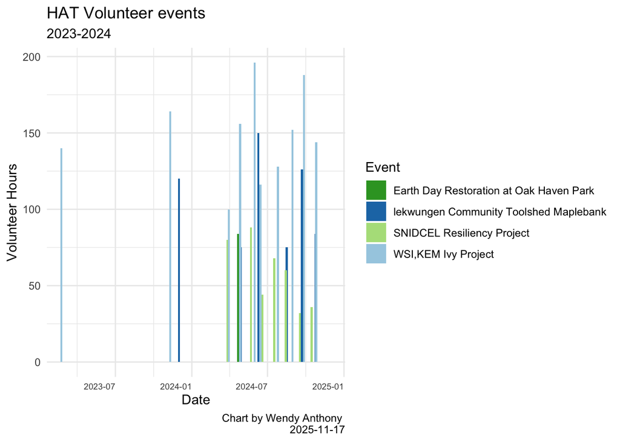

```r
custom_colours_4 <- c("WSI,KEM Ivy Project" = "#a6cee3",
                    "lekwungen Community Toolshed Maplebank" = "#1f78b4",
                    "SNIDCEL Resiliency Project" = "#b2df8a",
                    "Earth Day Restoration at Oak Haven Park" = "#33a02c")

HAT_data_Volevents_plot <-
  ggplot(HAT_data_Volevents, aes(x = Date, y = Volunteer_Hours, fill = Event)) +
  geom_bar(stat = "identity", width = 5, position = "dodge") +
  theme_minimal() + #get rid of grey background and tick marks
  theme(legend.position ="right") +
  theme(axis.text.x = element_text(angle = 0, vjust = 1, hjust=1, size = 7)) +
    scale_fill_manual(values = custom_colours_4) +
        labs(title='HAT Volunteer events',
          subtitle='2023-2024',
          caption = "Chart by Wendy Anthony \n 2025-11-17", fill = "Event",
          x = "Date", y = "Volunteer Hours")
HAT_data_Volevents_plot
```

## 9.2 Time Plots

### 9.2.1 Timevis

#### 9.2.1.1 OH Timevis

- each event needs a start and end time

```r
# https://github.com/daattali/timevis
library(timevis)


#   ?timevis()
# view minimal timeline
# timevis()

# create new file with changed column names for timevis
# change When to start
names(OH_timeline)[names(OH_timeline) == "When"] <- "start"
names(OH_timeline)[names(OH_timeline) == "What"] <- "content"
# add new column and duplicate When
# if an end date
# OH_timeline$end <- NA
# OH_timeline$end <- OH_timeline$start

OH_timeline
```

```
##                 content      start         EventType                    Where
## 1  OHP Monitoring Cover 2025-04-02     Cover_Monitor           Oak Haven Park
## 2  OHP Monitoring Cover 2025-04-03     Cover_Monitor           Oak Haven Park
## 3         OHP Treatment 2024-04-02   Treatment_Event           Oak Haven Park
## 4      HP Park Creation 2002-01-01      Park_Created           Havenwood Park
## 5     MCA Park Creation 1997-01-01      Park_Created Matson Conservation Area
## 6 OHP Covenant Creation 2004-01-01 Covenant_Creation           Oak Haven Park
##   LocationID             group  end
## 1        OHP        monitoring <NA>
## 2        OHP        monitoring <NA>
## 3        OHP         treatment <NA>
## 4         HP     park_creation <NA>
## 5        MCA     park_creation <NA>
## 6        OHP covenant_creation <NA>
```

```r
timevis(Timeline_OH_vis)
```

[interactive chart not shown]

#### 9.2.1.2 Create df for Timevis

```r
today <- as.character(Sys.Date())
hat_timedata <- data.frame(
      id = 1:5,
      start = c("2024-04-02", "2025-04-02", "2002-01-01", "1997-01-01", "2004-01-01"),
      end = c("2024-04-03", "2025-04-03", NA, NA, NA),
#      end = c("2024-04-03", "2025-04-03", today, today, today),
      # start = Sys.Date() + c(1, - 10, 4, 20, -10, 10),
      # end = c(rep(as.Date(NA), 4), Sys.Date(), Sys.Date() + 20),
      group = c(1,1,2,3,1),
      content = c("OHP Treatment", "OHP Monitoring Cover", "HP Park Creation", "MCA Park Creation", "OHP Covenant Creation")
      #,
      #subgroup = c("1.1", "1.2", "1.2", "2.1", "2.2", "2.2")
    )

timevis(hat_timedata)
```

[interactive chart not shown]

```r
# HAT_timevisDataGroups_what <- data.frame(
#   id = c("treat", "monitor", "park_creation", "covenant_creation"),
#   content = c("Treatment", "Monitoring", "Park Creation", "Covenant Creation")
# )
HAT_timevisDataGroups_where <- data.frame(
  id = 1:3,
  content = c("Oak Haven Park", "Havenwood Park", "Matson Conservation Area"),
  style = "font-weight: bold"
)

# timevis::timevis(data = hat_timedata, groups = HAT_timevisDataGroups_what, options = list(stack = TRUE))

timevis::timevis(data = hat_timedata, groups = HAT_timevisDataGroups_where, options = list(orientation = 'bottom'), showZoom = TRUE, zoomFactor = 0.5, fit = TRUE)
```

[interactive chart not shown]

```r
# horizontalScroll = TRUE, verticalScroll = TRUE not working
# zoomFactor = 0.5,
```

#### 9.2.1.3 test

#### 9.2.1.4 Group Timevis

- groups need ID and separate df
- each event needs a start and end time

```r
# https://github.com/daattali/timevis
library(timevis)
str(HAT_sites)
```

```
## 'data.frame':    3 obs. of  14 variables:
##  $ ID                   : chr  "OHP" "HP" "MCA"
##  $ Site                 : chr  "Oak Haven Park" "Havenwood Park" "Matson Conservation Area"
##  $ Lat                  : num  48.6 48.4 48.4
##  $ Lng                  : num  -123 -124 -123
##  $ Municipality         : chr  "Central Saanich" "Colwood" "Esquimalt"
##  $ FirstNations         : chr  "W̱SÁNEĆ" "Songhees, Esquimalt, WSANEC, Beecher Bay, T'Sou-ke" "Songhees, Esquimalt"
##  $ Park_Creation        : int  1997 2002 NA
##  $ HAT_Status           : chr  "Co-Covenant" "Co-Covenant" "Donation by Mandalay Developments Ltd."
##  $ Date                 : int  2004 NA 2004
##  $ Co_Covenant          : chr  "Land Conservancy" "City of Colwood" "Nature Conservancy of Canada; Township of Esquimalt"
##  $ Size_ha              : num  10.2 16.5 NA
##  $ Ecosystems           : chr  "" "5 wetlands; 3 small streams; 7 bedrock outcroppings" "Garry oak ecosystem"
##  $ Funding              : chr  "" "" "TD FEF; Sitka Foundation; Conservation Economic Stimulus Initiative; Habitat Conservation Trust Foundation; Env"| __truncated__
##  $ Volunteer_Stewardship: chr  "" "Friends of Havenwood Park" "Friends of Matson Lands"
```

```r
colnames(HAT_sites)
```

```
##  [1] "ID"                    "Site"                  "Lat"
##  [4] "Lng"                   "Municipality"          "FirstNations"
##  [7] "Park_Creation"         "HAT_Status"            "Date"
## [10] "Co_Covenant"           "Size_ha"               "Ecosystems"
## [13] "Funding"               "Volunteer_Stewardship"
```

```r
str(Timeline_OH_vis)
```

```
## 'data.frame':    3 obs. of  4 variables:
##  $ content  : chr  "OHP Monitoring Cover" "OHP Monitoring Cover" "OHP Treatment"
##  $ start    : chr  "2025-04-02" "2025-04-03" "2024-04-02"
##  $ EventType: chr  "Cover_Monitor" "Cover_Monitor" "Treatment_Event"
##  $ Where    : chr  "Oak Haven Park" "Oak Haven Park" "Oak Haven Park"
```

```r
colnames(Timeline_OH_vis)
```

```
## [1] "content"   "start"     "EventType" "Where"
```

```r
?timevis

HAT_timevisDataGroups <- data.frame(
  id = c("treat", "monitor", "park_creation", "covenant_creation"),
  content = c("Treatment", "Monitoring", "Park Creation", "Covenant Creation")
)
HAT_timevisDataGroups
```

```
##                  id           content
## 1             treat         Treatment
## 2           monitor        Monitoring
## 3     park_creation     Park Creation
## 4 covenant_creation Covenant Creation
```

```r
OH_timeline
```

```
##                 content      start         EventType                    Where
## 1  OHP Monitoring Cover 2025-04-02     Cover_Monitor           Oak Haven Park
## 2  OHP Monitoring Cover 2025-04-03     Cover_Monitor           Oak Haven Park
## 3         OHP Treatment 2024-04-02   Treatment_Event           Oak Haven Park
## 4      HP Park Creation 2002-01-01      Park_Created           Havenwood Park
## 5     MCA Park Creation 1997-01-01      Park_Created Matson Conservation Area
## 6 OHP Covenant Creation 2004-01-01 Covenant_Creation           Oak Haven Park
##   LocationID             group  end
## 1        OHP        monitoring <NA>
## 2        OHP        monitoring <NA>
## 3        OHP         treatment <NA>
## 4         HP     park_creation <NA>
## 5        MCA     park_creation <NA>
## 6        OHP covenant_creation <NA>
```

```r
timevis(Timeline_OH_vis)
```

[interactive chart not shown]

```r
timevis(OH_timeline)
```

[interactive chart not shown]

### 9.2.2 Timelines 1

`OH_timeline`

```r
# https://www.r4photobiology.info/galleries/plot-timeline.html
colnames(OH_timeline)
```

```
## [1] "content"    "start"      "EventType"  "Where"      "LocationID"
## [6] "group"      "end"
```

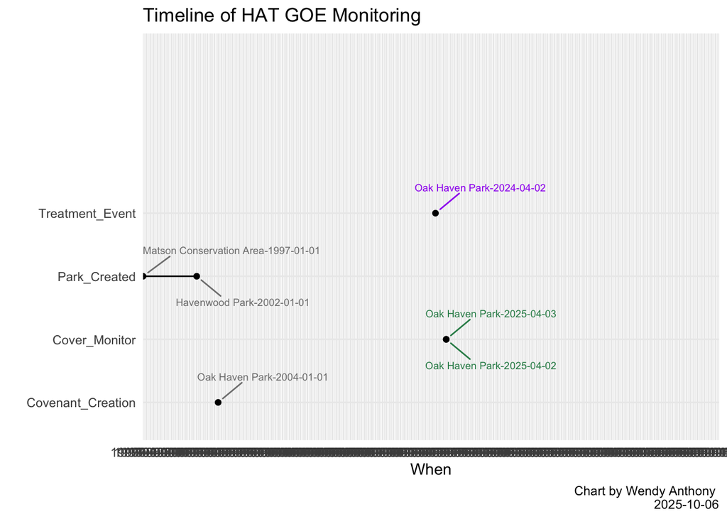

```r
library(ggrepel)
OH_timeline_plot <- ggplot(OH_timeline, aes(x = start, y = EventType, label = paste(Where, start, sep = "-"))) +
  # label = paste(wt, "^(", cyl, ")", sep = "")),
#OH_timeline_plot <- ggplot(OH_timeline, aes(x = When, y = EventType, label = What)) +

  geom_line() +
  geom_point(data = . %>% filter(Where != "")) +
  # geom_point(data = . %>% filter(What != "")) +
  # geom_text(aes(colour = EventType), hjust = -0.3, angle = 45) +
   # geom_text(size = 1.0) +
  #geom_text(aes(colour = EventType), hjust = -0.3, angle = 45, size = 3.0) +
   geom_text_repel(aes(colour = EventType),
     direction = "y",
                   size = 2.5,
                    point.padding = 0.5,
                    hjust = 0,
                    box.padding = 1,
                    seed = 123) +
  scale_x_date(name = "When", date_breaks = "4 months",
               expand = expansion(mult = c(0.0, 0.9))) +
              # expand = expansion(mult = c(0.05, 0.9))) +
  # coord_cartesian(xlim = c("2024-01-01", "2026-01-01")) +
  # scale_x_continuous(limits = c(2024-01-01, 2026-01-01)) +
  scale_y_discrete(name = "",
                   expand = expansion(mult = c(0.2, 0.95))) +
  scale_colour_manual(values = c(Cover_Monitor = "seagreen", Treatment_Event = "purple"), guide = "none") +
  theme_minimal() +
    labs(title='Timeline of HAT GOE Monitoring',
    # subtitle='HAT GOE Monitoring',
    # subtitl='Oak Haven Park',
    caption = "Chart by Wendy Anthony \n 2025-10-06")

OH_timeline_plot
```

### 9.2.3 Timelines 2

`OH_timeline`

```r
# https://www.r4photobiology.info/galleries/plot-timeline.html
colnames(OH_timeline)
```

```
## [1] "content"    "start"      "EventType"  "Where"      "LocationID"
## [6] "group"      "end"
```

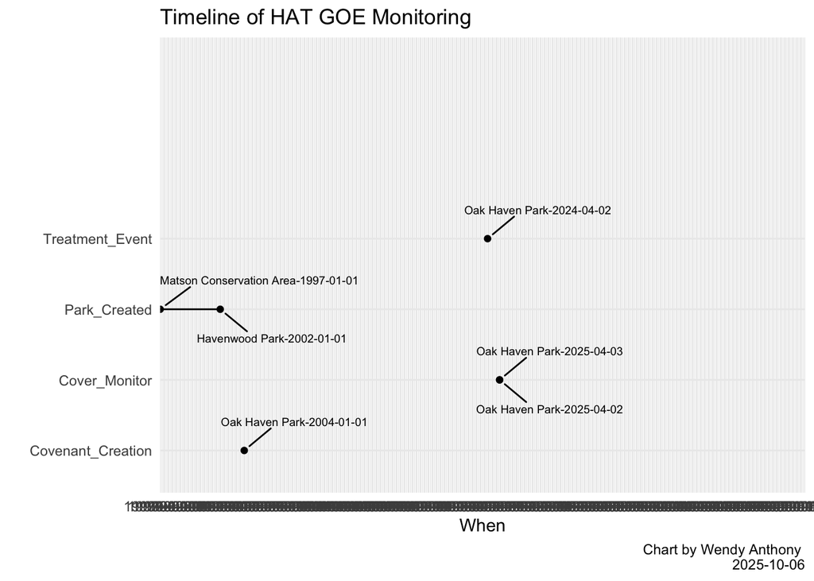

```r
library(ggrepel)
OH_timeline_plot <- ggplot(OH_timeline, aes(x = start, y = EventType, label = paste(Where, start, sep = "-"))) +
  # label = paste(wt, "^(", cyl, ")", sep = "")),
#OH_timeline_plot <- ggplot(OH_timeline, aes(x = When, y = EventType, label = What)) +

  geom_line() +
  geom_point(data = . %>% filter(Where != "")) +
  # geom_point(data = . %>% filter(What != "")) +
  # geom_text(aes(colour = EventType), hjust = -0.3, angle = 45) +
   # geom_text(size = 1.0) +
   geom_text_repel(direction = "y",
                   size = 2.5,
                    point.padding = 0.5,
                    hjust = 0,
                    box.padding = 1,
                    seed = 123) +
  scale_x_date(name = "When", date_breaks = "4 months",
               expand = expansion(mult = c(0.0, 0.9))) +
              # expand = expansion(mult = c(0.05, 0.9))) +
  # coord_cartesian(xlim = c("2024-01-01", "2026-01-01")) +
  # scale_x_continuous(limits = c(2024-01-01, 2026-01-01)) +
  scale_y_discrete(name = "",
                   expand = expansion(mult = c(0.2, 0.95))) +
  scale_colour_manual(values = c(Cover_Monitor = "seagreen", Treatment_Event = "purple"), guide = "none") +
  theme_minimal() +
    labs(title='Timeline of HAT GOE Monitoring',
    # subtitle='HAT GOE Monitoring',
    # subtitl='Oak Haven Park',
    caption = "Chart by Wendy Anthony \n 2025-10-06")

OH_timeline_plot
```

## 9.3 ggplot2 Charts

### 9.3.1 Species Richness by Treatment

```r
length(unique(oakhaven_2025_cover_sub_nat_tr$Species)) #11
```

```
## [1] 11
```

```r
length(unique(oakhaven_2025_cover_sub_inv_tr$Species)) #3
```

```
## [1] 3
```

```r
length(unique(oakhaven_2025_cover$Species)) #18
```

```
## [1] 20
```

```r
colnames(oakhaven_2025_cover)
```

```
##  [1] "SortID"             "MonitorID"          "QUniqueID"
##  [4] "Date"               "Year"               "Location"
##  [7] "Treated"            "YearTreated"        "ExSpTabTitle"
## [10] "Baseline"           "Quadrat"            "QuadratLocation_m"
## [13] "Species"            "Native_or_Invasive" "PercentCover"
## [16] "OriginalSpecies"
```

```r
oakhaven_2025_cover_sub <- oakhaven_2025_cover[-c(1:6,8:12,16)]
colnames(oakhaven_2025_cover_sub)
```

```
## [1] "Treated"            "Species"            "Native_or_Invasive"
## [4] "PercentCover"
```

```r
library(ggplot2)
library(magrittr) # required for %>%
library(plotly)

# https://ourcodingclub.github.io/tutorials/data-vis-2/
species_counts <- oakhaven_2025_cover_sub %>%
  dplyr::group_by(Treated, Native_or_Invasive) %>%
  dplyr::summarise(Species_number = length(unique(Species)))
colnames(species_counts) # [1] "Treated" "Native_or_Invasive" "Species_number"
```

```
## [1] "Treated"            "Native_or_Invasive" "Species_number"
```

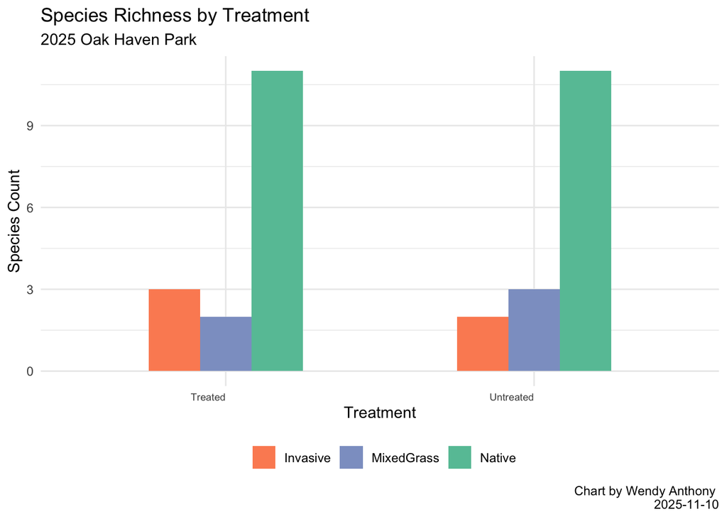

```r
# create custom colour-blind-friendly palette
custom_colours_3 <- c("Invasive" = "#fc8d62",
                    "Native" = "#66c2a5",
                    "MixedGrass" = "#8da0cb")
# custom_colours_3 <- c("Native" = "#1b9e77",
#                     "Invasive" = "#d95f02",
#                     "MixedGrass" = "#7570b3")

oakhaven_2025_sp_rich_treat_plot <-
  ggplot(species_counts, aes(x = Treated, y = Species_number, fill = Native_or_Invasive)) +
  geom_bar(stat = "identity", width = 0.5, position = "dodge") +
  theme_minimal() + #get rid of grey background and tick marks
  theme(legend.position ="bottom") +
  theme(axis.text.x = element_text(angle = 0, vjust = 1, hjust=1, size = 7)) +
    scale_fill_manual(values = custom_colours_3) +
        labs(title='Species Richness by Treatment',
          subtitle='2025 Oak Haven Park',
          caption = "Chart by Wendy Anthony \n 2025-11-10", fill = "",
          x = "Treatment", y = "Species Count")

oakhaven_2025_sp_rich_treat_plot
```

```r
# ggplotly
  ggplotly(oakhaven_2025_sp_rich_treat_plot)
```

[interactive chart not shown]

```r
# ggsave(filename = paste0("images/oakhaven_2025_sp_rich_treat_plot_", format(Sys.time(), "%Y-%m-%d_%H.%M"),".png"), oakhaven_2025_sp_rich_treat_plot)
```

#### 9.3.1.1 Species Richness by Native/Invasive

```r
length(unique(oakhaven_2025_cover_sub_nat_tr$Species)) #11
```

```
## [1] 11
```

```r
length(unique(oakhaven_2025_cover_sub_inv_tr$Species)) #3
```

```
## [1] 3
```

```r
length(unique(oakhaven_2025_cover$Species)) #18
```

```
## [1] 20
```

```r
colnames(oakhaven_2025_cover)
```

```
##  [1] "SortID"             "MonitorID"          "QUniqueID"
##  [4] "Date"               "Year"               "Location"
##  [7] "Treated"            "YearTreated"        "ExSpTabTitle"
## [10] "Baseline"           "Quadrat"            "QuadratLocation_m"
## [13] "Species"            "Native_or_Invasive" "PercentCover"
## [16] "OriginalSpecies"
```

```r
oakhaven_2025_cover_sub <- oakhaven_2025_cover[-c(1:6,8:12,16)]
colnames(oakhaven_2025_cover_sub)
```

```
## [1] "Treated"            "Species"            "Native_or_Invasive"
## [4] "PercentCover"
```

```r
library(ggplot2)
library(magrittr) # required for %>%
library(plotly)

species_counts <- oakhaven_2025_cover_sub %>%
  dplyr::group_by(Treated, Native_or_Invasive) %>%
  dplyr::summarise(Species_number = length(unique(Species)))
colnames(species_counts) # [1] "Treated" "Native_or_Invasive" "Species_number"
```

```
## [1] "Treated"            "Native_or_Invasive" "Species_number"
```

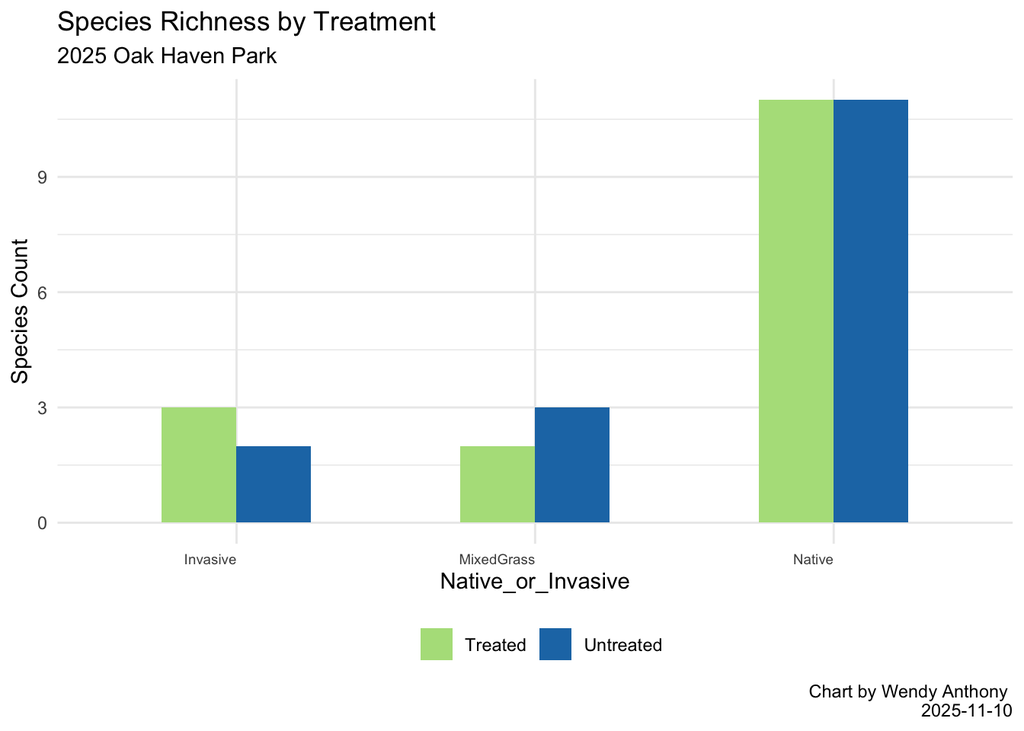

```r
# create custom colour-blind-friendly palette
custom_colours_4 <- c("Treated" = "#b2df8a",
                    "Untreated" = "#1f78b4")

oakhaven_2025_sp_rich_nat_inv_plot <-
  ggplot(species_counts, aes(x = Native_or_Invasive, y = Species_number, fill = Treated)) +
  geom_bar(stat = "identity", width = 0.5, position = "dodge") +
  theme_minimal() + #get rid of grey background and tick marks
  theme(legend.position ="bottom") +
  theme(axis.text.x = element_text(angle = 0, vjust = 1, hjust=1, size = 7)) +
    scale_fill_manual(values = custom_colours_4) +
        labs(title='Species Richness by Treatment',
          subtitle='2025 Oak Haven Park',
          caption = "Chart by Wendy Anthony \n 2025-11-10", fill = "",
          #x = "Native / Invasive",
          y = "Species Count")

oakhaven_2025_sp_rich_nat_inv_plot
```

```r
# ggplotly
  # ggplotly(oakhaven_2025_sp_rich_nat_inv_plot)
    ggplotly(tooltip = c("x", "y", "fill"), oakhaven_2025_sp_rich_nat_inv_plot) %>%
      config(displayModeBar = FALSE) %>% # This line disables the modebar
      layout(title = list(
        text = "Comparing Species Richness<br><sup>2025 Oak Haven Park</sup>",
        y = 0.95), # Adjust vertical position if needed
        xaxis = list(title = NA),
        yaxis = list(title = 'Species Count'),
        legend = list(x=0.4,
                                 xanchor='left',
                                 yanchor='bottom',
                                 orientation='h'),
        annotations = list(x = 1, y = -0.1, text = "Chart by Wendy Anthony\n2025-11-10",
             showarrow = F, xref='paper', yref='paper',
             xanchor='right', yanchor= 'auto', xshift=0, yshift=0,
             font = list(size=8, color="grey")
             ))
```

[interactive chart not shown]

```r
# ggsave(filename = paste0("images/oakhaven_2025_sp_rich_nat_inv_plot_", format(Sys.time(), "%Y-%m-%d_%H.%M"),".png"), oakhaven_2025_sp_rich_nat_inv_plot)
```

### 9.3.2 Quadrat per Species

```r
colnames(oakhaven_group_quadrats)
```

```
##  [1] "SortID"             "MonitorID"          "QUniqueID"
##  [4] "Date"               "Year"               "Location"
##  [7] "Treated"            "YearTreated"        "ExSpTabTitle"
## [10] "Baseline"           "Quadrat"            "QuadratLocation_m"
## [13] "Species"            "Native_or_Invasive" "PercentCover"
## [16] "OriginalSpecies"
```

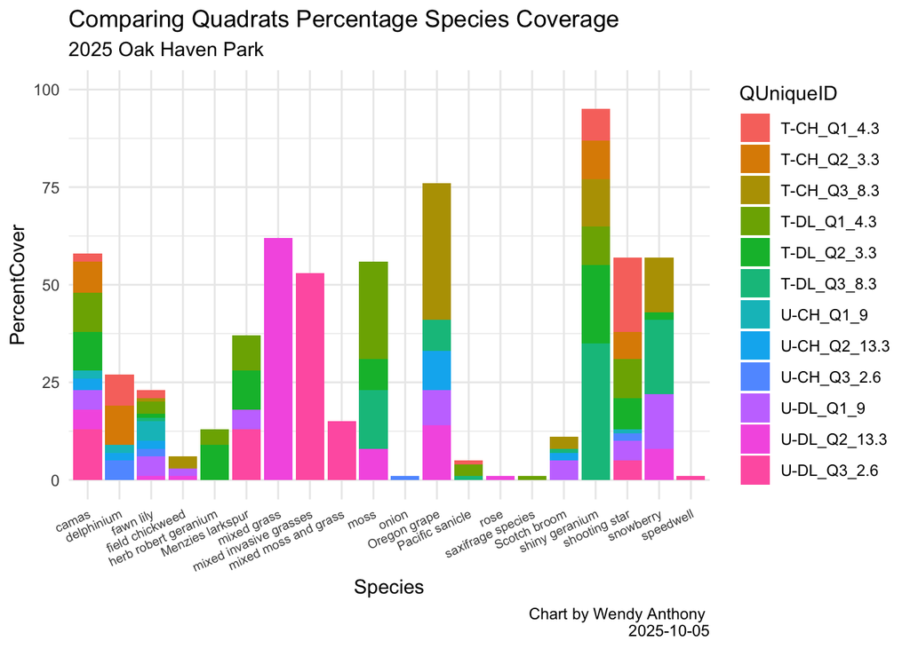

```r
oakhaven_group_quadrats_species_plot  <-  ggplot(oakhaven_group_quadrats,
                    aes(x = Species, y = PercentCover, fill = QUniqueID)) +
                      ylim(0, 100) +
                    #geom_bar(stat = "identity", fill = "seagreen") +
                    geom_bar(stat = "identity") +
                    theme_minimal() + #get rid of grey background and tick marks
                    # theme(legend.position="none") + #remove legend
                    theme(axis.text.x = element_text(angle = 25, vjust = 1, hjust=1, size = 7)) +
                    labs(title='Comparing Quadrats Percentage Species Coverage',
                      subtitle='2025 Oak Haven Park',
                      caption = "Chart by Wendy Anthony \n 2025-10-05")
oakhaven_group_quadrats_species_plot
```

```r
# ggsave(filename = paste0("images/oakhaven_group_quadrats_species_plot_", format(Sys.time(), "%Y-%m-%d_%H.%M"),".png"), oakhaven_group_quadrats_species_plot)

## ggplotly
    ggplotly(tooltip = c("x", "y", "color", "fill"), oakhaven_group_quadrats_species_plot) %>%
      config(displayModeBar = FALSE) %>% # This line disables the modebar
      layout(title = list(
        text = "Comparing Quadrats Percentage Species Coverage<br><sup>2025 Oak Haven Park</sup>",
        y = 0.95), # Adjust vertical position if needed
        xaxis = list(title = 'Unique Quadrat'),
        yaxis = list(title = 'Percentage Cover'),
        annotations = list(x = 1, y = -0.1, text = "Chart by Wendy Anthony\n2025-10-05",
             showarrow = F, xref='paper', yref='paper',
             xanchor='right', yanchor= 'auto', xshift=0, yshift=0,
             font = list(size=8, color="grey")
             ))
```

[interactive chart not shown]

### 9.3.3 Species per Quadrat

```r
colnames(oakhaven_group_quadrats)
```

```
##  [1] "SortID"             "MonitorID"          "QUniqueID"
##  [4] "Date"               "Year"               "Location"
##  [7] "Treated"            "YearTreated"        "ExSpTabTitle"
## [10] "Baseline"           "Quadrat"            "QuadratLocation_m"
## [13] "Species"            "Native_or_Invasive" "PercentCover"
## [16] "OriginalSpecies"
```

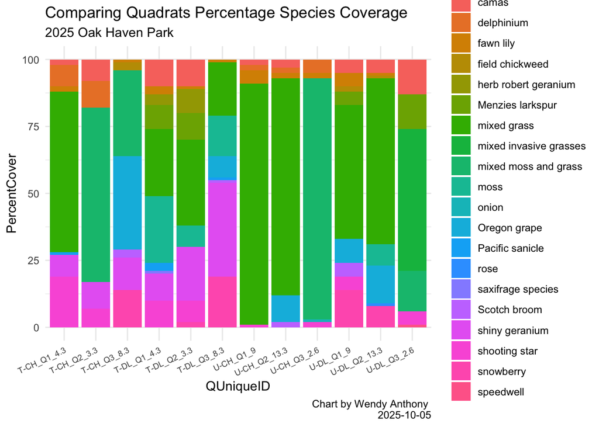

```r
oakhaven_group_quadrats_species_plot  <-  ggplot(oakhaven_group_quadrats,
                    aes(x = QUniqueID, y = PercentCover, fill = Species)) +
                      ylim(0, 100) +
                    #geom_bar(stat = "identity", fill = "seagreen") +
                    geom_bar(stat = "identity") +
                    theme_minimal() + #get rid of grey background and tick marks
                    theme(legend.title=element_blank()) +
                    theme(axis.text.x = element_text(angle = 25, vjust = 1, hjust=1, size = 7)) +
                    labs(title='Comparing Quadrats Percentage Species Coverage',
                      subtitle='2025 Oak Haven Park',
                      caption = "Chart by Wendy Anthony \n 2025-10-05")
oakhaven_group_quadrats_species_plot
```

```r
# ggsave(filename = paste0("images/oakhaven_group_quadrats_species_plot_", format(Sys.time(), "%Y-%m-%d_%H.%M"),".png"), oakhaven_group_quadrats_species_plot)

## ggplotly
    ggplotly(tooltip = c("x", "y", "color", "fill"), oakhaven_group_quadrats_species_plot) %>%
      config(displayModeBar = FALSE) %>% # This line disables the modebar
      layout(title = list(
        text = "Comparing Quadrats Percentage Species Coverage<br><sup>Oak Haven Park</sup>",
        y = 0.95), # Adjust vertical position if needed
        xaxis = list(title = 'Unique Quadrat'),
        yaxis = list(title = 'Percentage Cover'),
        annotations = list(x = 1, y = -0.1, text = "Chart by Wendy Anthony\n2025-10-05"
              # no legend
                           ,
             showarrow = F, xref='paper', yref='paper',
             xanchor='right', yanchor= 'auto', xshift=0, yshift=0,
             font = list(size=8, color="grey")
             )
        )
```

[interactive chart not shown]

### 9.3.4 Native vs Invasive per Quadrat

```r
colnames(oakhaven_2025_cover)
```

```
##  [1] "SortID"             "MonitorID"          "QUniqueID"
##  [4] "Date"               "Year"               "Location"
##  [7] "Treated"            "YearTreated"        "ExSpTabTitle"
## [10] "Baseline"           "Quadrat"            "QuadratLocation_m"
## [13] "Species"            "Native_or_Invasive" "PercentCover"
## [16] "OriginalSpecies"
```

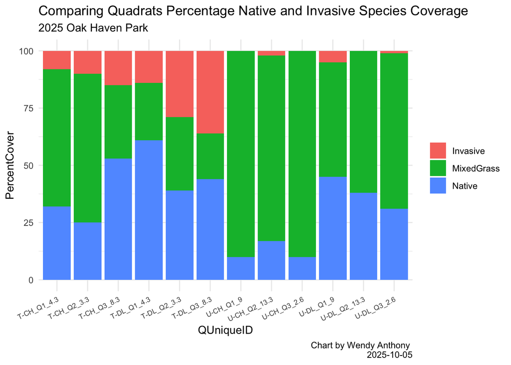

```r
oakhaven_group_quadrats_nat_inv_plot  <-  ggplot(oakhaven_2025_cover,
                    aes(x = QUniqueID, y = PercentCover, fill = Native_or_Invasive)) +
                      ylim(0, 100) +
                    #geom_bar(stat = "identity", fill = "seagreen") +
                    geom_bar(stat = "identity") +
                    theme_minimal() + #get rid of grey background and tick marks
                    # theme(legend.position="none") + #remove legend
                    theme(legend.title=element_blank()) +
                    theme(axis.text.x = element_text(angle = 25, vjust = 1, hjust=1, size = 7)) +
                    labs(title='Comparing Quadrats Percentage Native and Invasive Species Coverage',
                      subtitle='2025 Oak Haven Park',
                      caption = "Chart by Wendy Anthony \n 2025-10-05")
oakhaven_group_quadrats_nat_inv_plot
```

```r
# ggsave(filename = paste0("images/oakhaven_group_quadrats_nat_inv_plot_", format(Sys.time(), "%Y-%m-%d_%H.%M"),".png"), oakhaven_group_quadrats_nat_inv_plot)

## ggplotly
    ggplotly(tooltip = c("x", "y", "color", "fill"), oakhaven_group_quadrats_nat_inv_plot) %>%
      config(displayModeBar = FALSE) %>% # This line disables the modebar
      layout(title = list(
        text = "Comparing Quadrats Percentage Native/Invasive Coverage<br><sup>Oak Haven Park</sup>",
        y = 0.95), # Adjust vertical position if needed
        xaxis = list(title = 'Unique Quadrat'),
        yaxis = list(title = 'Percentage Cover'),
        legend = list(title = list(text = NA)),
        annotations = list(x = 1, y = -0.1, text = "Chart by Wendy Anthony\n2025-10-05"
              # no legend
                           ,
             showarrow = F, xref='paper', yref='paper',
             xanchor='right', yanchor= 'auto', xshift=0, yshift=0,
             font = list(size=8, color="grey")
             ))
```

[interactive chart not shown]

### 9.3.5 ??? Native Species per Quadrat

```r
colnames(oakhaven_group_quadrats)
```

```
##  [1] "SortID"             "MonitorID"          "QUniqueID"
##  [4] "Date"               "Year"               "Location"
##  [7] "Treated"            "YearTreated"        "ExSpTabTitle"
## [10] "Baseline"           "Quadrat"            "QuadratLocation_m"
## [13] "Species"            "Native_or_Invasive" "PercentCover"
## [16] "OriginalSpecies"
```

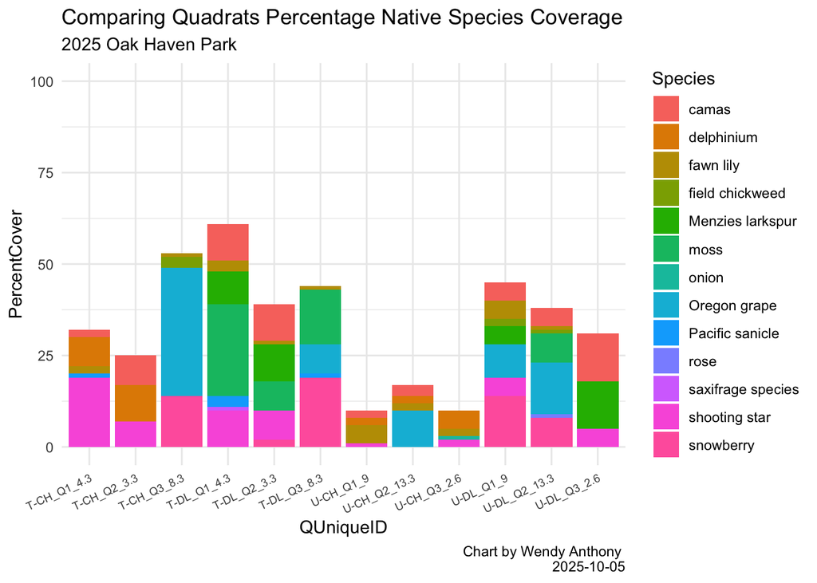

```r
oakhaven_2025_cover_nat_plot  <-  ggplot(oakhaven_2025_cover_nat,
                    aes(x = QUniqueID, y = PercentCover, fill = Species)) +
                      ylim(0, 100) +
                    #geom_bar(stat = "identity", fill = "seagreen") +
                    geom_bar(stat = "identity") +
                    theme_minimal() + #get rid of grey background and tick marks
                    # theme(legend.position="none") + #remove legend
                    theme(axis.text.x = element_text(angle = 25, vjust = 1, hjust=1, size = 7)) +
                    labs(title='Comparing Quadrats Percentage Native Species Coverage',
                      subtitle='2025 Oak Haven Park',
                      caption = "Chart by Wendy Anthony \n 2025-10-05")

oakhaven_2025_cover_nat_plot
```

```r
# ggsave(filename = paste0("images/oakhaven_2025_cover_nat_plot_", format(Sys.time(), "%Y-%m-%d_%H.%M"),".png"), oakhaven_2025_cover_nat_plot)

## ggplotly
    ggplotly(tooltip = c("x", "y", "color", "fill"), oakhaven_2025_cover_nat_plot) %>%
      config(displayModeBar = FALSE) %>% # This line disables the modebar
      layout(title = list(
        text = "Comparing Quadrats Percentage Native Species Coverage<br><sup>Oak Haven Park</sup>",
        y = 0.95), # Adjust vertical position if needed
        xaxis = list(title = 'Unique Quadrat'),
        yaxis = list(title = 'Percentage Cover'),
        annotations = list(x = 1, y = -0.1, text = "Chart by Wendy Anthony\n2025-10-05"
              # no legend
                           ,
             showarrow = F, xref='paper', yref='paper',
             xanchor='right', yanchor= 'auto', xshift=0, yshift=0,
             font = list(size=8, color="grey")
             ))
```

[interactive chart not shown]

### 9.3.6 ?? Invasive Species per Quadrat

- without Mixed Grasses

```r
colnames(oakhaven_2025_cover_inv)
```

```
##  [1] "SortID"             "MonitorID"          "QUniqueID"
##  [4] "Date"               "Year"               "Location"
##  [7] "Treated"            "YearTreated"        "ExSpTabTitle"
## [10] "Baseline"           "Quadrat"            "QuadratLocation_m"
## [13] "Species"            "Native_or_Invasive" "PercentCover"
## [16] "OriginalSpecies"
```

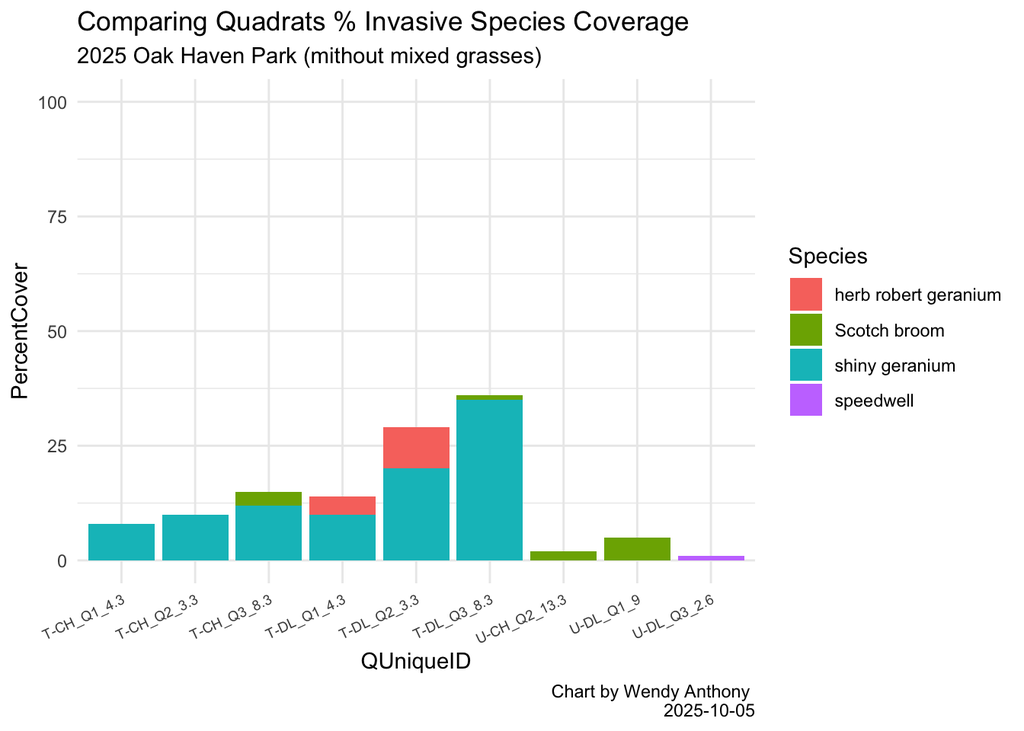

```r
oakhaven_2025_cover_inv_plot  <-  ggplot(oakhaven_2025_cover_inv,
                    aes(x = QUniqueID, y = PercentCover, fill = Species)) +
                      ylim(0, 100) +
                    #geom_bar(stat = "identity", fill = "seagreen") +
                    geom_bar(stat = "identity") +
                    theme_minimal() + #get rid of grey background and tick marks
                    # theme(legend.position="none") + #remove legend
                    theme(axis.text.x = element_text(angle = 25, vjust = 1, hjust=1, size = 7)) +
                    labs(title='Comparing Quadrats % Invasive Species Coverage',
                      subtitle='2025 Oak Haven Park (mithout mixed grasses)',
                      caption = "Chart by Wendy Anthony \n 2025-10-05")

oakhaven_2025_cover_inv_plot
```

```r
## ggplotly
    ggplotly(tooltip = c("x", "y", "color", "fill"), oakhaven_2025_cover_inv_plot) %>%
      config(displayModeBar = FALSE) %>% # This line disables the modebar
      layout(title = list(
        text = "Comparing Quadrats % Invasive Species Coverage<br><sup>Oak Haven Park (without mixed grasses)</sup>",
        y = 0.95), # Adjust vertical position if needed
        xaxis = list(title = 'Unique Quadrat'),
        yaxis = list(title = 'Percentage Cover'),
        annotations = list(x = 1, y = -0.1, text = "Chart by Wendy Anthony\n2025-10-05"
              # no legend
                           ,
             showarrow = F, xref='paper', yref='paper',
             xanchor='right', yanchor= 'auto', xshift=0, yshift=0,
             font = list(size=8, color="grey")
             ))
```

[interactive chart not shown]

### 9.3.7 Mixed Grass and Moss per Quadrat

```r
colnames(oakhaven_2025_cover_mix)
```

```
##  [1] "SortID"             "MonitorID"          "QUniqueID"
##  [4] "Date"               "Year"               "Location"
##  [7] "Treated"            "YearTreated"        "ExSpTabTitle"
## [10] "Baseline"           "Quadrat"            "QuadratLocation_m"
## [13] "Species"            "Native_or_Invasive" "PercentCover"
## [16] "OriginalSpecies"
```

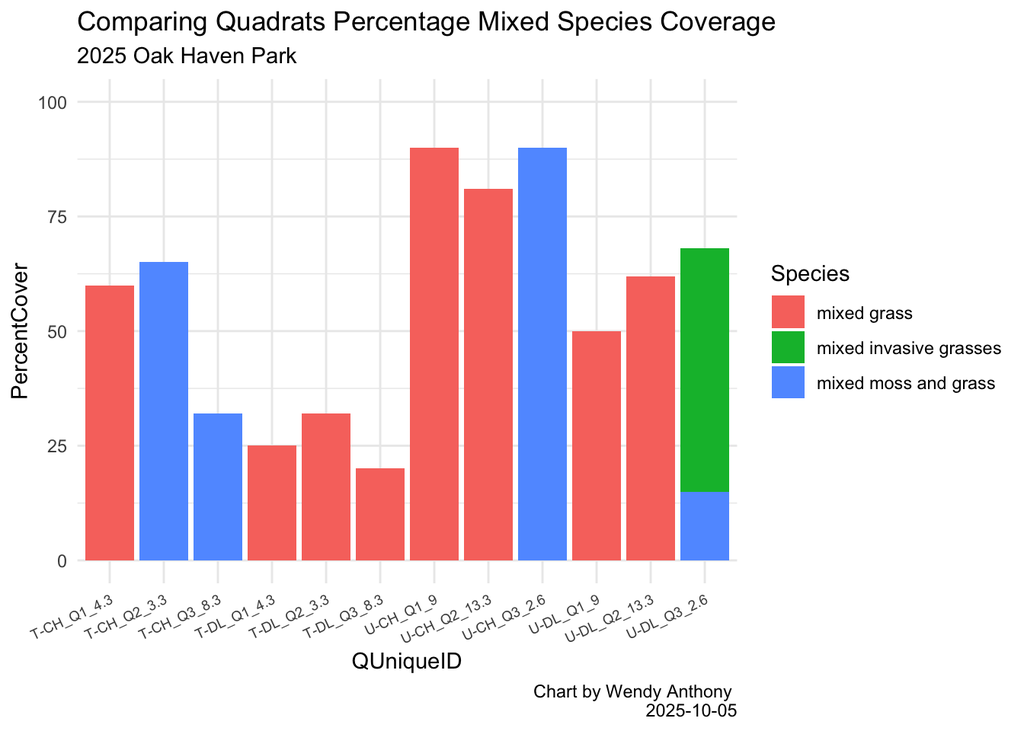

```r
oakhaven_2025_cover_mix_plot  <-  ggplot(oakhaven_2025_cover_mix,
                    aes(x = QUniqueID, y = PercentCover, fill = Species)) +
                      ylim(0, 100) +
                    #geom_bar(stat = "identity", fill = "seagreen") +
                    geom_bar(stat = "identity") +
                    theme_minimal() + #get rid of grey background and tick marks
                    # theme(legend.position="none") + #remove legend
                    theme(axis.text.x = element_text(angle = 25, vjust = 1, hjust=1, size = 7)) +
                    labs(title='Comparing Quadrats Percentage Mixed Species Coverage',
                      subtitle='2025 Oak Haven Park',
                      caption = "Chart by Wendy Anthony \n 2025-10-05")

oakhaven_2025_cover_mix_plot
```

```r
## ggplotly
    ggplotly(tooltip = c("x", "y", "color", "fill"), oakhaven_2025_cover_mix_plot) %>%
      config(displayModeBar = FALSE) %>% # This line disables the modebar
      layout(title = list(
        text = "Comparing Quadrats Percent Cover Mixed Grass & Moss <br><sup>Oak Haven Park</sup>",
        y = 0.95), # Adjust vertical position if needed
        xaxis = list(title = 'Unique Quadrat'),
        yaxis = list(title = 'Percentage Cover'),
        annotations = list(x = 1, y = -0.1, text = "Chart by Wendy Anthony\n2025-10-05"
              # no legend
                           ,
             showarrow = F, xref='paper', yref='paper',
             xanchor='right', yanchor= 'auto', xshift=0, yshift=0,
             font = list(size=8, color="grey")
             ))
```

[interactive chart not shown]

### 9.3.8 ??? Native Species cover per quadrat

- Warning to knit `("Must request at least one colour from a hue palette."`

```r
# # colnames(oakhaven_2025_cover_nat)
#
# oakhaven_2025_cover_nat_plot  <-  ggplot(oakhaven_2025_cover_nat,
#                     aes(x = Species, y = PercentCover, fill = QUniqueID)) +
#                       ylim(0, 100) +
#                     #geom_bar(stat = "identity", fill = "seagreen") +
#                     geom_bar(stat = "identity") +
#                     theme_minimal() + #get rid of grey background and tick marks
#                     # theme(legend.position="none") + #remove legend
#                     theme(axis.text.x = element_text(angle = 25, vjust = 1, hjust=1, size = 7)) +
#                     labs(title='Comparing Quadrats Percentage Native Species Coverage',
#                       subtitle='2025 Oak Haven Park',
#                       caption = "Chart by Wendy Anthony \n 2025-10-05")
# oakhaven_2025_cover_nat_plot
#
# ## ggplotly
#     ggplotly(tooltip = c("x", "y", "fill"), oakhaven_2025_cover_nat_plot) %>%
#       config(displayModeBar = FALSE) %>% # This line disables the modebar
#       layout(title = list(
#         text = "Comparing Quadrats Percentage Species Coverage<br><sup>Oak Haven Park</sup>",
#         y = 0.95), # Adjust vertical position if needed
#         xaxis = list(title = 'Unique Quadrat'),
#         yaxis = list(title = 'Percentage Cover'),
#         annotations = list(x = 1, y = -0.1, text = "Chart by Wendy Anthony\n2025-10-05"
#               # no legend
#                            ,
#              showarrow = F, xref='paper', yref='paper',
#              xanchor='right', yanchor= 'auto', xshift=0, yshift=0,
#              font = list(size=8, color="grey")
#              )
#         )
```

## 9.4 ** Violin Plot Mean Percentage Cover Native / Invasive Untreated

```r
oakhaven_2025_cover_untreat_sp_mean
```

```
## # A tibble: 16 × 3
##    Species                meanPercentCover Native_or_Invasive
##    <chr>                             <dbl> <chr>
##  1 Menzies larkspur                   9    Native
##  2 Oregon grape                      11    Native
##  3 Scotch broom                       3.5  Invasive
##  4 camas                              5.6  Native
##  5 delphinium                         3    Native
##  6 fawn lily                          3    Native
##  7 field chickweed                    1.5  Native
##  8 mixed grass                       70.8  MixedGrass
##  9 mixed invasive grasses            53    MixedGrass
## 10 mixed moss and grass              52.5  MixedGrass
## 11 moss                               8    Native
## 12 onion                              1    Native
## 13 rose                               1    Native
## 14 shooting star                      3.25 Native
## 15 snowberry                         11    Native
## 16 speedwell                          1    Invasive
```

```r
colnames(oakhaven_2025_cover_untreat_sp_mean)
```

```
## [1] "Species"            "meanPercentCover"   "Native_or_Invasive"
```

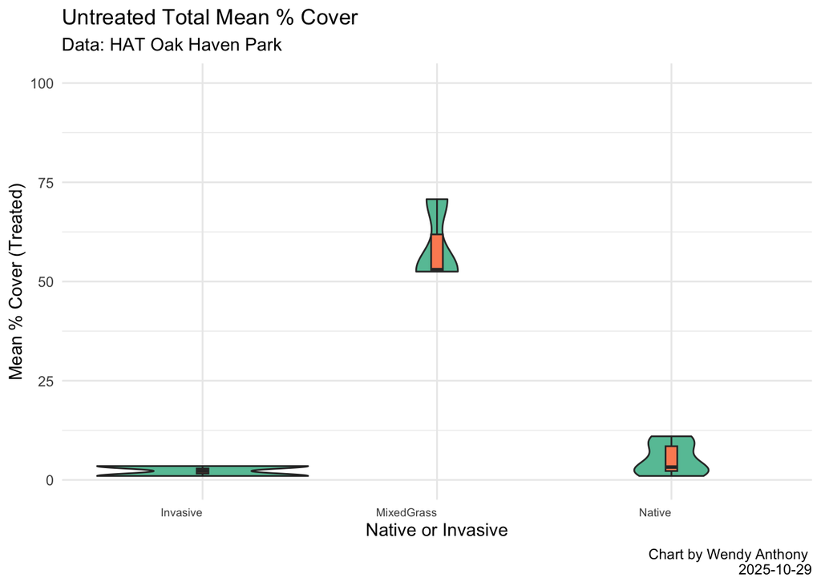

```r
    oakhaven_2025_cover_untreat_sp_mean_violinPlot <- ggplot(oakhaven_2025_cover_untreat_sp_mean,
       # text = paste("Site:", Site),
      aes(x = Native_or_Invasive, y = meanPercentCover)) +
      geom_violin(fill = "#66c2a5") +
      geom_boxplot(width = 0.05, fill = "#fc8d62") +
      theme_minimal() + #get rid of grey background and tick marks
      theme(legend.position="bottom") +
      theme(axis.text.x = element_text(angle = 0, vjust = 1, hjust=1, size = 7)) +
      scale_y_continuous(limits = c(0, 100)) +
      labs(title='Untreated Total Mean % Cover',
           subtitle='Data: HAT Oak Haven Park',
           caption = "Chart by Wendy Anthony \n 2025-10-29",
           x = "Native or Invasive",
           y = "Mean % Cover (Treated)")

oakhaven_2025_cover_untreat_sp_mean_violinPlot
```

```r
# ggsave(filename = paste0("images/oakhaven_2025_cover_untreat_sp_mean_violinPlot_", format(Sys.time(), "%Y-%m-%d_%H.%M"),".png"), oakhaven_2025_cover_untreat_sp_mean_violinPlot)
  # plotly
# ggplotly(oakhaven_2025_cover_untreat_sp_mean_violinPlot)
```

## 9.5 ** Violin Plot Mean Percentage Cover Native / Invasive Treated

```r
oakhaven_2025_cover_treat_sp_mean
```

```
## # A tibble: 16 × 3
##    Species              meanPercentCover Native_or_Invasive
##    <chr>                           <dbl> <chr>
##  1 Menzies larkspur                 9.5  Native
##  2 Oregon grape                    21.5  Native
##  3 Pacific sanicle                  1.67 Native
##  4 Scotch broom                     2    Invasive
##  5 camas                            7.5  Native
##  6 delphinium                       9    Native
##  7 fawn lily                        1.6  Native
##  8 field chickweed                  3    Native
##  9 herb robert geranium             6.5  Invasive
## 10 mixed grass                     34.2  MixedGrass
## 11 mixed moss and grass            48.5  MixedGrass
## 12 moss                            16    Native
## 13 saxifrage species                1    Native
## 14 shiny geranium                  15.8  Invasive
## 15 shooting star                   11    Native
## 16 snowberry                       11.7  Native
```

```r
colnames(oakhaven_2025_cover_treat_sp_mean)
```

```
## [1] "Species"            "meanPercentCover"   "Native_or_Invasive"
```

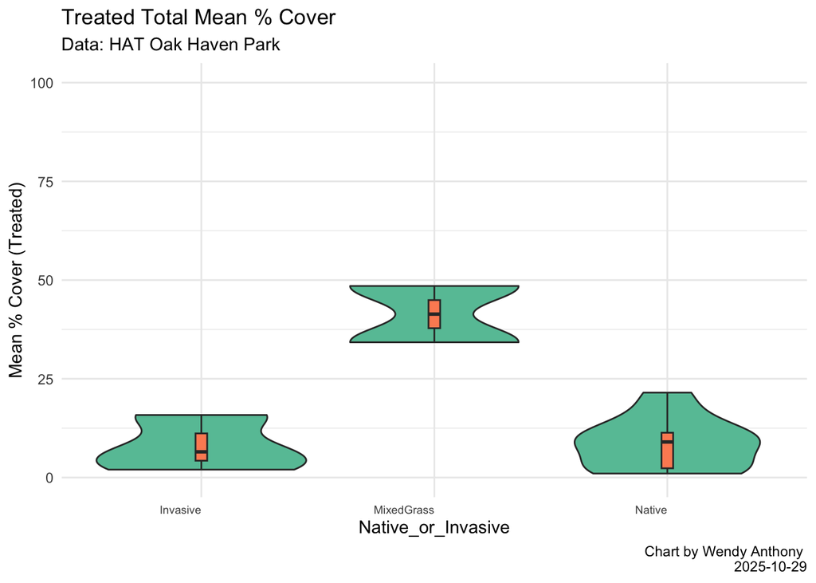

```r
    oakhaven_2025_cover_treat_sp_mean_violinPlot <- ggplot(oakhaven_2025_cover_treat_sp_mean,
      aes(x = Native_or_Invasive, y = meanPercentCover)) +
      geom_violin(fill = "#66c2a5") +
      geom_boxplot(width = 0.05, fill = "#fc8d62") +
      theme_minimal() + #get rid of grey background and tick marks
      theme(legend.position="bottom") +
      theme(axis.text.x = element_text(angle = 0, vjust = 1, hjust=1, size = 7)) +
      scale_y_continuous(limits = c(0, 100)) +
      labs(title='Treated Total Mean % Cover',
           subtitle='Data: HAT Oak Haven Park',
           caption = "Chart by Wendy Anthony \n 2025-10-29",
           y = "Mean % Cover (Treated)")

    oakhaven_2025_cover_treat_sp_mean_violinPlot
```

```r
    # ggsave(filename = paste0("images/oakhaven_2025_cover_treat_sp_mean_violinPlot_", format(Sys.time(), "%Y-%m-%d_%H.%M"),".png"), oakhaven_2025_cover_treat_sp_mean_violinPlot)
```

### 9.5.1 ** Combine 2 Violin plots

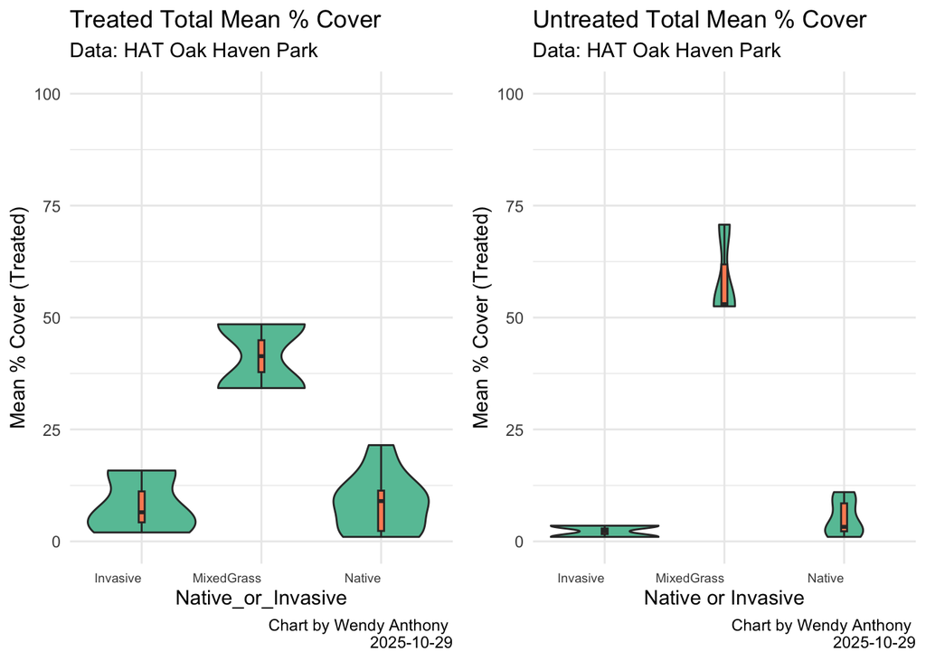

```r
# library(gridExtra)
oakhaven_2025_cover_tr_untr_mean_violinPlot <- grid.arrange(arrangeGrob(oakhaven_2025_cover_treat_sp_mean_violinPlot, oakhaven_2025_cover_untreat_sp_mean_violinPlot, ncol = 2))
```

```r
oakhaven_2025_cover_tr_untr_mean_violinPlot
```

```r
# ggsave(filename = paste0("images/compare_mean_sd_treat_untreat_violin_", format(Sys.time(), "%Y-%m-%d_%H.%M"),".png"), oakhaven_2025_cover_tr_untr_mean_violinPlot)
# ggsave("images/compare_mean_sd_treat_untreat_violin.png", oakhaven_2025_cover_tr_untr_mean_violinPlot)
```

## 9.6 Compare Treat to Untreat

### 9.6.1 Mean Cover Species plot all

- using colour-blind-friendly palette

```r
colnames(oakhaven_2025_cover_mean_by_group_species)
```

```
## [1] "Species"            "Treated"            "Native_or_Invasive"
## [4] "mean_value"         "sd_value"
```

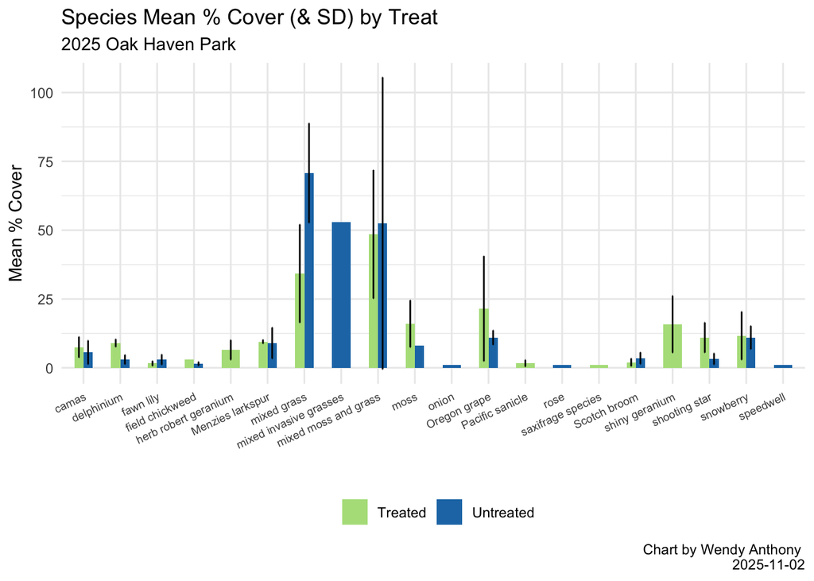

```r
# create custom colour-blind-friendly palette
custom_colours_2 <- c("Treated" = "#b2df8a",
                    "Untreated" = "#1f78b4")

oakhaven_2025_cover_mean_by_group_species_plot <- ggplot(oakhaven_2025_cover_mean_by_group_species, aes(Species, mean_value, fill = Treated)) +
  geom_bar(stat = "identity", width = 0.5, position = "dodge") +
  geom_errorbar(aes(ymin = mean_value - sd_value, ymax = mean_value + sd_value), width =.02, position = position_dodge(0.5)) +
  theme_minimal() + #get rid of grey background and tick marks
  theme(legend.position ="bottom") +
  theme(axis.text.x = element_text(angle = 25, vjust = 1, hjust=1, size = 7)) +
    scale_fill_manual(values = custom_colours_2) +
        labs(title='Species Mean % Cover (& SD) by Treat',
          subtitle='2025 Oak Haven Park',
          caption = "Chart by Wendy Anthony \n 2025-11-02",
          x = "", y = "Mean % Cover", fill = "")

oakhaven_2025_cover_mean_by_group_species_plot
```

```r
# ggsave(filename = paste0("images/oakhaven_2025_cover_mean_by_group_species_plot_", format(Sys.time(), "%Y-%m-%d_%H.%M"),".png"), oakhaven_2025_cover_mean_by_group_species_plot)
```

### 9.6.2 Mean Cover Species plot all - no grass

- using colour-blind-friendly palette

```r
colnames(oakhaven_2025_cover_mean_by_group_species)
```

```
## [1] "Species"            "Treated"            "Native_or_Invasive"
## [4] "mean_value"         "sd_value"
```

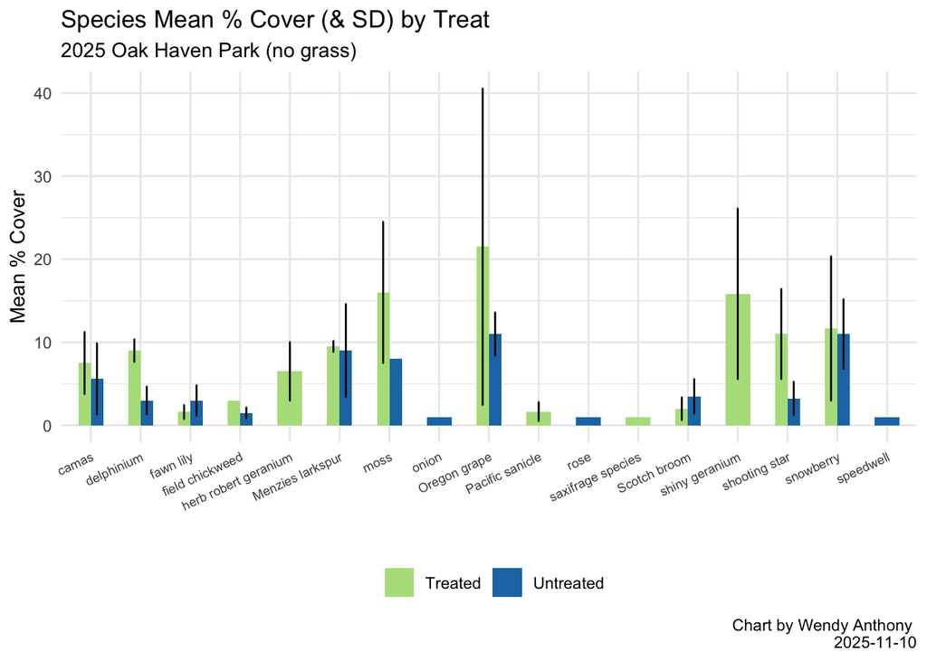

```r
# create custom colour-blind-friendly palette
custom_colours_2 <- c("Treated" = "#b2df8a",
                    "Untreated" = "#1f78b4")

oakhaven_2025_cover_mean_by_group_species_nograss_plot <- oakhaven_2025_cover_mean_by_group_species %>%
  filter(Native_or_Invasive != "MixedGrass") %>%
  ggplot(aes(Species, mean_value, fill = Treated)) +
  geom_bar(stat = "identity", width = 0.5, position = "dodge") +
  geom_errorbar(aes(ymin = mean_value - sd_value, ymax = mean_value + sd_value), width =.02, position = position_dodge(0.5)) +
  theme_minimal() + #get rid of grey background and tick marks
  theme(legend.position ="bottom") +
  theme(axis.text.x = element_text(angle = 25, vjust = 1, hjust=1, size = 7)) +
    scale_fill_manual(values = custom_colours_2) +
        labs(title='Species Mean % Cover (& SD) by Treat',
          subtitle='2025 Oak Haven Park (no grass)',
          caption = "Chart by Wendy Anthony \n 2025-11-10",
          x = "", y = "Mean % Cover", fill = "")

oakhaven_2025_cover_mean_by_group_species_nograss_plot
```

```r
# ggsave(filename = paste0("images/oakhaven_2025_cover_mean_by_group_species_nograss_plot_", format(Sys.time(), "%Y-%m-%d_%H.%M"),".png"), oakhaven_2025_cover_mean_by_group_species_nograss_plot)
```

### 9.6.3 ** Combine 2 Bar Dodge plots

Comparing All Species Mean % Cover (and Standard Deviation) by Treatment

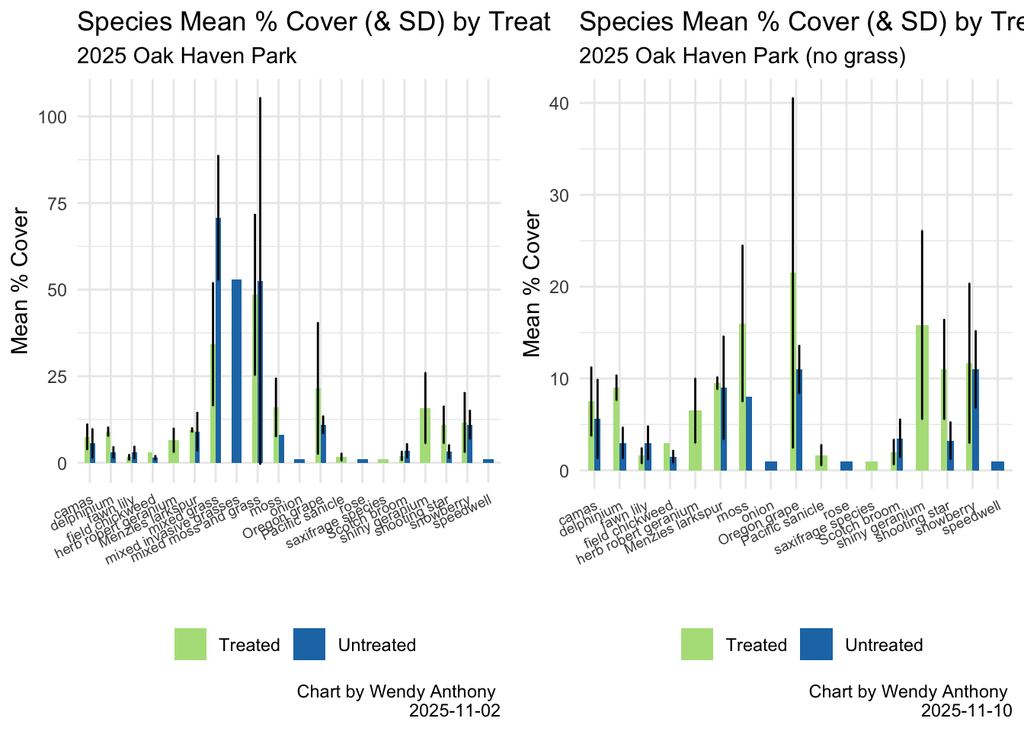

```r
# library(gridExtra)

combine_oakhaven_2025_cover_tr_untr_mean_bar_dodge_Plot <- grid.arrange(arrangeGrob(oakhaven_2025_cover_mean_by_group_species_plot, oakhaven_2025_cover_mean_by_group_species_nograss_plot, ncol = 2))
```

```r
# ggsave(filename = paste0("images/combine_oakhaven_2025_cover_tr_untr_mean_bar_dodge_Plot_", format(Sys.time(), "%Y-%m-%d_%H.%M"),".png"), combine_oakhaven_2025_cover_tr_untr_mean_bar_dodge_Plot)
```

### 9.6.4 ** Mean Cover Species plot native

```r
colnames(oakhaven_2025_cover_mean_by_group_species)
```

```
## [1] "Species"            "Treated"            "Native_or_Invasive"
## [4] "mean_value"         "sd_value"
```

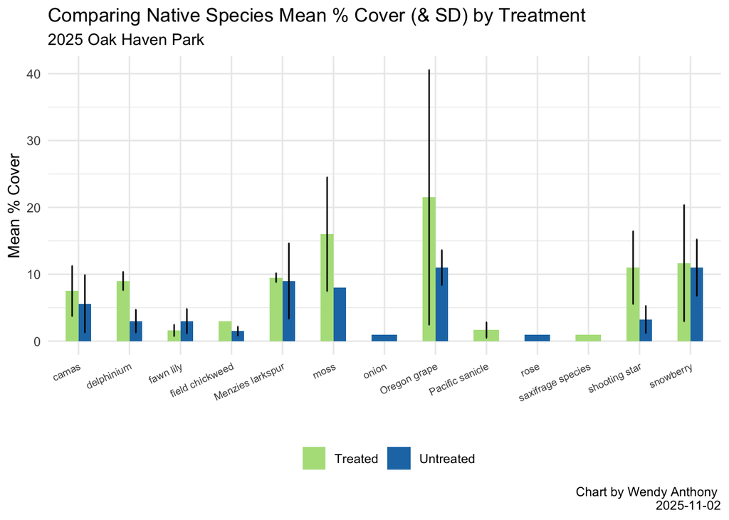

```r
oakhaven_2025_cover_mean_by_group_species_nat <- oakhaven_2025_cover_mean_by_group_species[oakhaven_2025_cover_mean_by_group_species$Native_or_Invasive == "Native",]

# create custom colour-blind-friendly palette
custom_colours_2 <- c("Treated" = "#b2df8a",
                    "Untreated" = "#1f78b4")

oakhaven_2025_cover_mean_by_group_species_nat_plot <- ggplot(oakhaven_2025_cover_mean_by_group_species_nat, aes(Species, mean_value, fill = Treated)) +
  geom_bar(stat = "identity", width = 0.5, position = "dodge") +
  geom_errorbar(aes(ymin = mean_value - sd_value, ymax = mean_value + sd_value), width =.02, position = position_dodge(0.5)) +
  theme_minimal() + #get rid of grey background and tick marks
  theme(legend.position ="bottom") +
  theme(axis.text.x = element_text(angle = 25, vjust = 1, hjust=1, size = 7)) +
    scale_fill_manual(values = custom_colours_2) +
        labs(title='Comparing Native Species Mean % Cover (& SD) by Treatment',
          subtitle='2025 Oak Haven Park',
          caption = "Chart by Wendy Anthony \n 2025-11-02",
          x = "", y = "Mean % Cover", fill = "")
oakhaven_2025_cover_mean_by_group_species_nat_plot
```

```r
# ggsave(filename = paste0("images/oakhaven_2025_cover_mean_by_group_species_nat_barplot_", format(Sys.time(), "%Y-%m-%d_%H.%M"),".png"), oakhaven_2025_cover_mean_by_group_species_nat_plot)

# ggsave("images/oakhaven_2025_cover_mean_by_group_species_nat_barplot.png", oakhaven_2025_cover_mean_by_group_species_nat_plot)
```

### 9.6.5 ** Mean Cover Species plot invasive

```r
colnames(oakhaven_2025_cover_mean_by_group_species)
```

```
## [1] "Species"            "Treated"            "Native_or_Invasive"
## [4] "mean_value"         "sd_value"
```

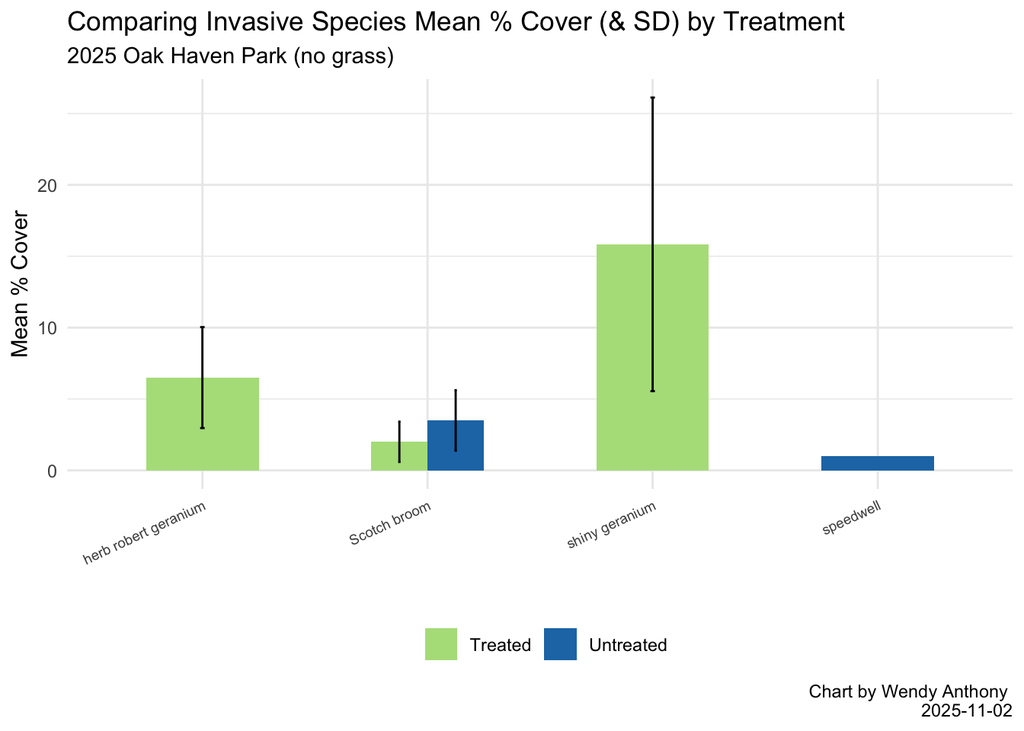

```r
oakhaven_2025_cover_mean_by_group_species_inv <- oakhaven_2025_cover_mean_by_group_species[oakhaven_2025_cover_mean_by_group_species$Native_or_Invasive == "Invasive",]

# create custom colour-blind-friendly palette
custom_colours_2 <- c("Treated" = "#b2df8a",
                    "Untreated" = "#1f78b4")

oakhaven_2025_cover_mean_by_group_species_inv_plot <- ggplot(oakhaven_2025_cover_mean_by_group_species_inv, aes(Species, mean_value, fill = Treated)) +
  geom_bar(stat = "identity", width = 0.5, position = "dodge") +
    geom_errorbar(aes(ymin = mean_value - sd_value, ymax = mean_value + sd_value), width =.02, position = position_dodge(0.5)) +
  theme_minimal() + #get rid of grey background and tick marks
  theme(legend.position ="bottom") +
  theme(axis.text.x = element_text(angle = 25, vjust = 1, hjust=1, size = 7)) +
    scale_fill_manual(values = custom_colours_2) +
        labs(title='Comparing Invasive Species Mean % Cover (& SD) by Treatment',
          subtitle='2025 Oak Haven Park (no grass)',
          caption = "Chart by Wendy Anthony \n 2025-11-02",
          x = "", y = "Mean % Cover", fill = "")

oakhaven_2025_cover_mean_by_group_species_inv_plot
```

```r
# ggsave(filename = paste0("images/oakhaven_2025_cover_mean_by_group_species_inv_barplot_", format(Sys.time(), "%Y-%m-%d_%H.%M"),".png"), oakhaven_2025_cover_mean_by_group_species_inv_plot)

# ggsave("images/oakhaven_2025_cover_mean_by_group_species_inv_barplot.png", oakhaven_2025_cover_mean_by_group_species_inv_plot)
```

### 9.6.6 Mean Cover Treated plot

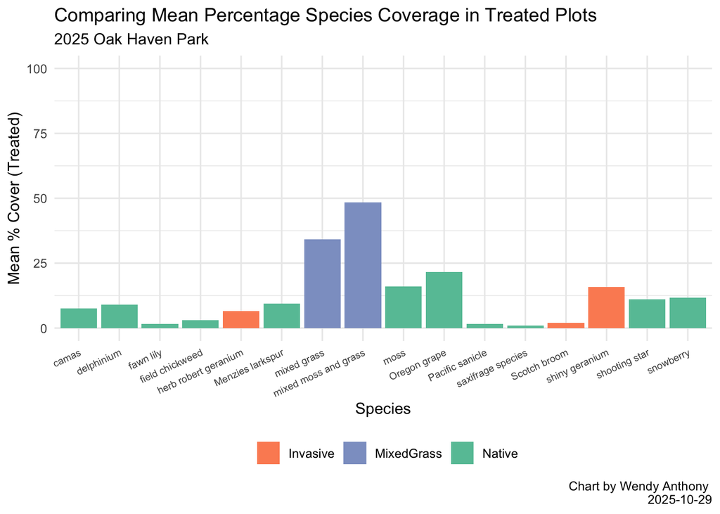

```r
# create custom colour-blind-friendly palette
custom_colours <- c("Invasive" = "#fc8d62",
                    "Native" = "#66c2a5",
                    "MixedGrass" = "#8da0cb")

oakhaven_2025_cover_treat_sp_mean_plot  <- ggplot(oakhaven_2025_cover_treat_sp_mean,
      aes(x = Species, y = meanPercentCover, fill = Native_or_Invasive)) +
      ylim(0, 100) +
      geom_bar(stat = "identity") +
      scale_fill_manual(values = custom_colours, name = "Native/Invasive") +
      theme_minimal() + #get rid of grey background and tick marks
      theme(legend.position ="bottom") +
      theme(legend.title=element_blank()) +
      theme(axis.text.x = element_text(angle = 25, vjust = 1, hjust=1, size = 7)) +
      labs(title='Comparing Mean Percentage Species Coverage in Treated Plots',
           subtitle='2025 Oak Haven Park',
           caption = "Chart by Wendy Anthony \n 2025-10-29",
           y = "Mean % Cover (Treated)")

oakhaven_2025_cover_treat_sp_mean_plot
```

```r
# ggsave(filename = paste0("images/oakhaven_2025_cover_treat_sp_mean_plot_", format(Sys.time(), "%Y-%m-%d_%H.%M"),".png"), oakhaven_2025_cover_treat_sp_mean_plot)
```

### 9.6.7 Mean Cover Treated plot no grass

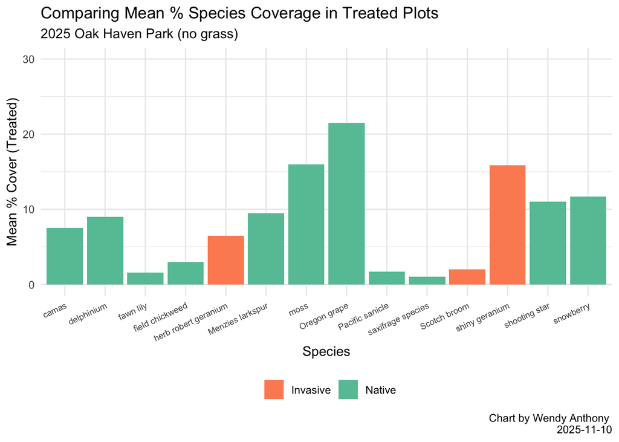

```r
# create custom colour-blind-friendly palette
custom_colours <- c("Invasive" = "#fc8d62",
                    "Native" = "#66c2a5",
                    "MixedGrass" = "#8da0cb")

oakhaven_2025_cover_treat_sp_mean_nograss_plot <- oakhaven_2025_cover_treat_sp_mean %>%
  filter(Native_or_Invasive != "MixedGrass") %>%
ggplot(
      aes(x = Species, y = meanPercentCover, fill = Native_or_Invasive)) +
      ylim(0, 30) +
      geom_bar(stat = "identity") +
      scale_fill_manual(values = custom_colours, name = "Native/Invasive") +
      theme_minimal() + #get rid of grey background and tick marks
      theme(legend.position ="bottom") +
      theme(legend.title=element_blank()) +
      theme(axis.text.x = element_text(angle = 25, vjust = 1, hjust=1, size = 7)) +
      labs(title='Comparing Mean % Species Coverage in Treated Plots',
           subtitle='2025 Oak Haven Park (no grass)',
           caption = "Chart by Wendy Anthony \n 2025-11-10",
           y = "Mean % Cover (Treated)")

oakhaven_2025_cover_treat_sp_mean_nograss_plot
```

```r
# ggsave(filename = paste0("images/oakhaven_2025_cover_treat_sp_mean_nograss_plot_", format(Sys.time(), "%Y-%m-%d_%H.%M"),".png"), oakhaven_2025_cover_treat_sp_mean_nograss_plot)
```

#### 9.6.7.1 *** Sort Mean Cover Treated plot

```r
colnames(oakhaven_2025_cover_treat_sp_mean)
```

```
## [1] "Species"            "meanPercentCover"   "Native_or_Invasive"
```

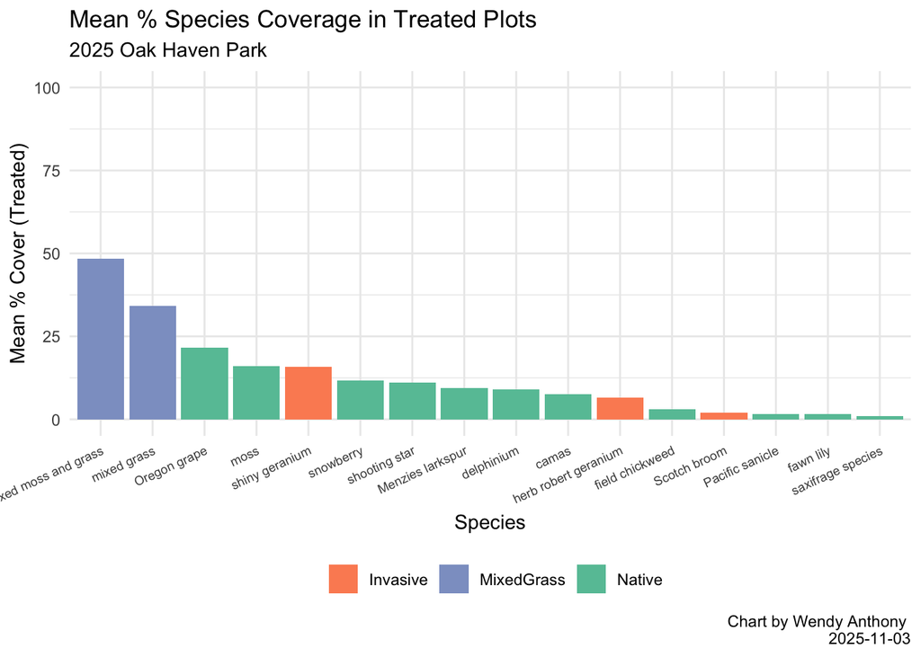

```r
# create custom colour-blind-friendly palette
custom_colours <- c("Invasive" = "#fc8d62",
                    "Native" = "#66c2a5",
                    "MixedGrass" = "#8da0cb")

oakhaven_2025_cover_treat_sp_mean_plot_sort  <- oakhaven_2025_cover_treat_sp_mean %>% arrange(desc(meanPercentCover)) %>%
  # updates Site with new arrangement
   mutate(Species = factor(Species, levels = Species)) %>%

  ggplot(
      aes(x = Species, y = meanPercentCover, fill = Native_or_Invasive)) +
      ylim(0, 100) +
      geom_bar(stat = "identity") +
      scale_fill_manual(values = custom_colours, name = "Native/Invasive") +
      theme_minimal() + #get rid of grey background and tick marks
      theme(legend.position="bottom") +
      theme(legend.title=element_blank()) +
      theme(axis.text.x = element_text(angle = 25, vjust = 1, hjust=1, size = 7)) +
      labs(title='Mean % Species Coverage in Treated Plots',
           subtitle='2025 Oak Haven Park',
           caption = "Chart by Wendy Anthony \n 2025-11-03",
           y = "Mean % Cover (Treated)")
oakhaven_2025_cover_treat_sp_mean_plot_sort
```

```r
# ggsave(filename = paste0("images/oakhaven_2025_cover_treat_sp_mean_plot_sort_barplot_", format(Sys.time(), "%Y-%m-%d_%H.%M"),".png"), oakhaven_2025_cover_treat_sp_mean_plot_sort)
#ggsave("images/oakhaven_2025_cover_treat_sp_mean_plot_sort_barplot.png", oakhaven_2025_cover_treat_sp_mean_plot_sort)
```